# Trip Rating CLassification

## 1- Initialization

### Introduction

You’re given our real dataset containing the information about trips completed for 30 days in some of our city . We randomly picked up all the rides taken by 9000 joyful customers and now we are giving them to you. Also, we’ve hidden 3000 customer rides as a testing dataset .

### Import Libraries

```python
#Essential Libraries
import pandas as pd
import numpy as np
from math import cos, asin, sqrt, pi
from scipy import stats
from scipy.stats import chi2
from datetime import datetime
import calendar



# Import Viz libraries
%matplotlib inline
import matplotlib
import matplotlib.pyplot as plt
import seaborn as sns
from pandas.plotting import scatter_matrix


#Modeling libraries
from sklearn import cross_validation
from sklearn import preprocessing
from sklearn.preprocessing import StandardScaler
from sklearn.datasets import load_svmlight_file
from sklearn.decomposition import PCA
from sklearn.preprocessing import Imputer
from sklearn.linear_model import LogisticRegression
from sklearn.ensemble import RandomForestClassifier
from sklearn.grid_search import GridSearchCV
from sklearn.ensemble import ExtraTreesClassifier
from sklearn.ensemble import GradientBoostingClassifier
from sklearn.externals import joblib
from sklearn.metrics import classification_report, f1_score, accuracy_score, confusion_matrix
from sklearn import svm, datasets, metrics, model_selection


from sklearn.metrics import roc_auc_score,confusion_matrix,roc_curve
from sklearn.neighbors import KNeighborsClassifier
from sklearn.svm import SVC
from sklearn.tree import DecisionTreeClassifier
from sklearn.naive_bayes import GaussianNB
from sklearn.discriminant_analysis import LinearDiscriminantAnalysis,QuadraticDiscriminantAnalysis
from scipy import stats


from sklearn.metrics import recall_score


import xgboost as xgb
from sklearn.preprocessing import LabelEncoder





from sklearn.linear_model import LogisticRegression #logistic regression
from sklearn import svm #support vector Machine


from sklearn.model_selection import train_test_split
from sklearn.model_selection import KFold #for K-fold cross validation
from sklearn.model_selection import cross_val_score #score evaluation
from sklearn.model_selection import cross_val_predict #prediction
from sklearn.model_selection import StratifiedKFold,RandomizedSearchCV
from sklearn.model_selection import StratifiedShuffleSplit
from sklearn.model_selection import GridSearchCV


# Load scikit's random forest classifier library
from sklearn.ensemble import AdaBoostClassifier
from sklearn.ensemble import GradientBoostingClassifier
from sklearn.ensemble import RandomForestClassifier #Random Forest



pd.set_option('display.max_columns', 500)

#remove margins
from IPython.core.display import display, HTML
display(HTML("<style>"
    + "#notebook { padding-top:0px !important; } "
    + ".container { width:100% !important; } "
    + ".end_space { min-height:0px !important; } "
    + "</style>"))

#interactive
from IPython.core.interactiveshell import InteractiveShell
InteractiveShell.ast_node_interactivity = "all"

#Remove Warnings
import warnings
warnings.filterwarnings('ignore')
```

### Define the functions

Define the functions that will be used across the notebook

```python
# Function to use through out the program

#identify outliers  using IQR method
def outliers_iqr(ys):
    quartile_1, quartile_3 = np.percentile(ys, [25, 99])# originally it was 25,75, adjusted to avoid removing many records
    iqr = quartile_3 - quartile_1
    lower_bound = quartile_1 - (iqr * 1.5)
    upper_bound = quartile_3 + (iqr * 1.5)
    return np.where((ys > upper_bound) | (ys < lower_bound))
    #return np.where((ys > upper_bound) )


def ConvertSpeed(df, ColName):
#     filter_values = [0,25, 50,150]
#     filter_values = [0,10, 20,30,40,50,60]
    newcol = ColName+'_bin'
#     df[newcol] = pd.cut(df[ColName], bins = filter_values, labels= ["Slow","Midium","Fast"])
    df[newcol] = pd.cut(df[ColName], bins = 10, labels= range(1,11))
    return df


def timeOfDay(triptimestamp):
    hour = triptimestamp.hour
    if hour >= 5 and hour <12: return 'Morning'
    elif hour >= 12 and hour <17: return 'Afternoon'
    elif hour >= 17 and hour <21: return 'Evening'
    else :return 'Night'


def OneHotEncoderfunc(df, colList):
    c2 = []
    for c in colList:
        if df[c].nunique()>2 :
            c2.append(c)
            #c3[c] = 'ohe_'+c
    print(f'Before : {df.shape}')
    df = pd.get_dummies(df,columns=c2,drop_first=False)#prefix=c3)
    print(f'After : {df.shape}')
    return df
```

### Read data files

```python
trip_train = pd.read_csv("data/train.csv",index_col=0)
```

```python
trip_test = pd.read_csv("data/test.csv",index_col=0)
#test_ID = test.ID
```

```python
trip_rating = pd.read_csv("data/trip_rating.csv",index_col=0)
```

## 2-Exploratory Data Analysis (EDA) and Adjustments

### Inital Metadata Dicsovery & Adjustement

Analyze the column structure, data types, stats. Drop/Rename columns

```python
print (f'Training Dataset shape: {trip_train.shape}')
print (f'Test Dataset shape: {trip_test.shape}')
```

```
Training Dataset shape: (51083, 17)
Test Dataset shape: (17201, 15)
```

```python
trip_train.head()
```

|  | customer_id | driver_id | creation_date | booking_source | car_type | estimated_distance | distance_travelled | distance_travelled_while_moving | estimated_duration | duration_time | wait_time_initial | wait_time_in_journey | estimated_price | price | is_cancelled | rating | was_rated |
| --- | --- | --- | --- | --- | --- | --- | --- | --- | --- | --- | --- | --- | --- | --- | --- | --- | --- |
| 0 | 52400320 | 1838640 | 2017-09-08 11:32:05.000 | 1 | 1 | 0.0 | 7.28666 | 7.17712 | 0 | 11 | 18 | 2 | 0.0 | 17.375184 | 0 | 4 | 1 |
| 1 | 29858456 | 1793472 | 2017-09-08 12:42:33.000 | 1 | 1 | 0.0 | 1.25836 | 1.05664 | 0 | 4 | 1 | 1 | 0.0 | 8.507064 | 0 | 4 | 1 |
| 2 | 30828968 | 1726788 | 2017-09-08 12:46:42.000 | 2 | 1 | 0.0 | 14.57820 | 14.44060 | 0 | 16 | 3 | 2 | 0.0 | 19.745205 | 0 | 5 | 1 |
| 3 | 47974768 | 1181696 | 2017-09-08 13:52:35.000 | 2 | 1 | 0.0 | 1.51911 | 1.18684 | 0 | 8 | 0 | 5 | 0.0 | 10.968003 | 0 | 0 | 0 |
| 4 | 59503764 | 2063752 | 2017-09-08 14:18:47.000 | 2 | 1 | 0.0 | 11.09320 | 10.67240 | 0 | 19 | 1 | 4 | 0.0 | 17.595398 | 0 | 5 | 1 |

```python
trip_test.head()
```

|  | customer_id | driver_id | creation_date | booking_source | car_type | estimated_distance | distance_travelled | distance_travelled_while_moving | estimated_duration | duration_time | wait_time_initial | wait_time_in_journey | estimated_price | price | is_cancelled |
| --- | --- | --- | --- | --- | --- | --- | --- | --- | --- | --- | --- | --- | --- | --- | --- |
| 0 | 60956364 | 1761208 | 2017-09-08 15:11:09.000 | 1 | 1 | 0.0 | 14.58090 | 13.63340 | 0 | 35 | 0 | 14 | 0.0 | 20.581726 | 0 |
| 1 | 60777268 | 1863028 | 2017-09-08 15:17:00.000 | 2 | 1 | 0.0 | 3.11665 | 2.78458 | 0 | 9 | 1 | 3 | 0.0 | 10.968003 | 0 |
| 2 | 55197228 | 1362580 | 2017-09-08 20:54:56.000 | 1 | 1 | 0.0 | 8.15772 | 7.48073 | 0 | 16 | 0 | 5 | 0.0 | 15.186146 | 0 |
| 3 | 53877020 | 1917600 | 2017-09-09 07:15:20.000 | 2 | 1 | 0.0 | 9.10110 | 8.39143 | 0 | 29 | 2 | 14 | 0.0 | 17.724573 | 0 |
| 4 | 12747160 | 2063780 | 2017-09-09 10:38:21.000 | 2 | 1 | 0.0 | 16.02280 | 15.32200 | 0 | 57 | 1 | 34 | 0.0 | 23.929555 | 0 |

```python
#change column names to lower case
trip_train.columns = [x.lower() for x in trip_train.columns]
trip_test.columns = [x.lower() for x in trip_test.columns]
```

```python
# Check Number of NaNs for each column
trip_train.isnull().sum(axis=0)
```

```
customer_id                        0
driver_id                          0
creation_date                      0
booking_source                     0
car_type                           0
estimated_distance                 0
distance_travelled                 0
distance_travelled_while_moving    0
estimated_duration                 0
duration_time                      0
wait_time_initial                  0
wait_time_in_journey               0
estimated_price                    0
price                              0
is_cancelled                       0
rating                             0
was_rated                          0
dtype: int64
```

```python
trip_train.count()
trip_train.info()
trip_train.describe()
```

```
customer_id                        51083
driver_id                          51083
creation_date                      51083
booking_source                     51083
car_type                           51083
estimated_distance                 51083
distance_travelled                 51083
distance_travelled_while_moving    51083
estimated_duration                 51083
duration_time                      51083
wait_time_initial                  51083
wait_time_in_journey               51083
estimated_price                    51083
price                              51083
is_cancelled                       51083
rating                             51083
was_rated                          51083
dtype: int64
```

```
<class 'pandas.core.frame.DataFrame'>
Int64Index: 51083 entries, 0 to 51082
Data columns (total 17 columns):
customer_id                        51083 non-null int64
driver_id                          51083 non-null int64
creation_date                      51083 non-null object
booking_source                     51083 non-null int64
car_type                           51083 non-null int64
estimated_distance                 51083 non-null float64
distance_travelled                 51083 non-null float64
distance_travelled_while_moving    51083 non-null float64
estimated_duration                 51083 non-null int64
duration_time                      51083 non-null int64
wait_time_initial                  51083 non-null int64
wait_time_in_journey               51083 non-null int64
estimated_price                    51083 non-null float64
price                              51083 non-null float64
is_cancelled                       51083 non-null int64
rating                             51083 non-null int64
was_rated                          51083 non-null int64
dtypes: float64(5), int64(11), object(1)
memory usage: 7.0+ MB
```

|  | customer_id | driver_id | booking_source | car_type | estimated_distance | distance_travelled | distance_travelled_while_moving | estimated_duration | duration_time | wait_time_initial | wait_time_in_journey | estimated_price | price | is_cancelled | rating | was_rated |
| --- | --- | --- | --- | --- | --- | --- | --- | --- | --- | --- | --- | --- | --- | --- | --- | --- |
| count | 5.108300e+04 | 5.108300e+04 | 51083.000000 | 51083.000000 | 51083.000000 | 51083.000000 | 51083.000000 | 51083.000000 | 51083.000000 | 51083.000000 | 51083.000000 | 51083.000000 | 51083.000000 | 51083.000000 | 51083.000000 | 51083.000000 |
| mean | 3.701478e+07 | 1.581080e+06 | 1.509817 | 1.111348 | 0.917110 | 6.810667 | 6.292355 | 1.929370 | 16.265392 | 2.471370 | 6.056301 | 1.681055 | 13.718933 | 0.042774 | 3.263121 | 0.682752 |
| std | 1.831212e+07 | 4.461198e+05 | 0.506677 | 0.446606 | 4.409016 | 6.671300 | 6.493241 | 6.426472 | 14.043821 | 2.960479 | 8.679217 | 5.413482 | 4.628049 | 0.202348 | 2.297473 | 0.465410 |
| min | 4.092000e+05 | 5.093000e+05 | 1.000000 | 1.000000 | 0.000000 | 0.000000 | 0.000000 | 0.000000 | 0.000000 | 0.000000 | -34.000000 | 0.000000 | 0.000000 | 0.000000 | 0.000000 | 0.000000 |
| 25% | 2.047212e+07 | 1.301384e+06 | 1.000000 | 1.000000 | 0.000000 | 3.199195 | 2.815185 | 0.000000 | 8.000000 | 0.000000 | 2.000000 | 0.000000 | 10.860325 | 0.000000 | 0.000000 | 0.000000 |
| 50% | 3.970655e+07 | 1.720492e+06 | 2.000000 | 1.000000 | 0.000000 | 5.358200 | 4.852870 | 0.000000 | 13.000000 | 2.000000 | 4.000000 | 0.000000 | 12.674608 | 0.000000 | 5.000000 | 1.000000 |
| 75% | 5.403015e+07 | 1.953104e+06 | 2.000000 | 1.000000 | 0.000000 | 8.565545 | 7.915150 | 0.000000 | 21.000000 | 3.000000 | 8.000000 | 0.000000 | 16.287307 | 0.000000 | 5.000000 | 1.000000 |
| max | 6.388676e+07 | 2.203644e+06 | 4.000000 | 6.000000 | 347.556000 | 325.504000 | 324.568000 | 232.000000 | 666.000000 | 73.000000 | 524.000000 | 72.522902 | 50.540852 | 1.000000 | 5.000000 | 1.000000 |

```python
trip_test.count()
trip_test.info()
trip_test.describe()
```

```
customer_id                        17201
driver_id                          17201
creation_date                      17201
booking_source                     17201
car_type                           17201
estimated_distance                 17201
distance_travelled                 17201
distance_travelled_while_moving    17201
estimated_duration                 17201
duration_time                      17201
wait_time_initial                  17201
wait_time_in_journey               17201
estimated_price                    17201
price                              17201
is_cancelled                       17201
dtype: int64
```

```
<class 'pandas.core.frame.DataFrame'>
Int64Index: 17201 entries, 0 to 17200
Data columns (total 15 columns):
customer_id                        17201 non-null int64
driver_id                          17201 non-null int64
creation_date                      17201 non-null object
booking_source                     17201 non-null int64
car_type                           17201 non-null int64
estimated_distance                 17201 non-null float64
distance_travelled                 17201 non-null float64
distance_travelled_while_moving    17201 non-null float64
estimated_duration                 17201 non-null int64
duration_time                      17201 non-null int64
wait_time_initial                  17201 non-null int64
wait_time_in_journey               17201 non-null int64
estimated_price                    17201 non-null float64
price                              17201 non-null float64
is_cancelled                       17201 non-null int64
dtypes: float64(5), int64(9), object(1)
memory usage: 2.1+ MB
```

|  | customer_id | driver_id | booking_source | car_type | estimated_distance | distance_travelled | distance_travelled_while_moving | estimated_duration | duration_time | wait_time_initial | wait_time_in_journey | estimated_price | price | is_cancelled |
| --- | --- | --- | --- | --- | --- | --- | --- | --- | --- | --- | --- | --- | --- | --- |
| count | 1.720100e+04 | 1.720100e+04 | 17201.000000 | 17201.000000 | 17201.000000 | 17201.000000 | 17201.000000 | 17201.000000 | 17201.000000 | 17201.000000 | 17201.000000 | 17201.000000 | 17201.000000 | 17201.000000 |
| mean | 3.795940e+07 | 1.578781e+06 | 1.487181 | 1.095169 | 0.906909 | 7.085442 | 6.543295 | 1.930411 | 17.038021 | 2.541887 | 6.431893 | 1.621049 | 13.985509 | 0.043544 |
| std | 1.767776e+07 | 4.505917e+05 | 0.508156 | 0.410276 | 3.837853 | 6.725035 | 6.535416 | 6.677390 | 14.015749 | 3.010757 | 8.722480 | 5.287823 | 4.700024 | 0.204084 |
| min | 5.770000e+05 | 5.093000e+05 | 1.000000 | 1.000000 | 0.000000 | 0.000000 | 0.000000 | 0.000000 | 0.000000 | 0.000000 | -34.000000 | 0.000000 | 0.000000 | 0.000000 |
| 25% | 2.190339e+07 | 1.295000e+06 | 1.000000 | 1.000000 | 0.000000 | 3.348630 | 2.966160 | 0.000000 | 9.000000 | 0.000000 | 2.000000 | 0.000000 | 10.968003 | 0.000000 |
| 50% | 4.104595e+07 | 1.720468e+06 | 1.000000 | 1.000000 | 0.000000 | 5.617430 | 5.095870 | 0.000000 | 14.000000 | 2.000000 | 4.000000 | 0.000000 | 13.095993 | 0.000000 |
| 75% | 5.370847e+07 | 1.957772e+06 | 2.000000 | 1.000000 | 0.000000 | 9.018770 | 8.364590 | 0.000000 | 22.000000 | 4.000000 | 8.000000 | 0.000000 | 16.671929 | 0.000000 |
| max | 6.388404e+07 | 2.203644e+06 | 4.000000 | 5.000000 | 111.276000 | 125.234000 | 124.196000 | 203.000000 | 315.000000 | 54.000000 | 209.000000 | 72.522902 | 44.903748 | 1.000000 |

### Understand the relatioship between the training and test datasets

- the purpose here is to understand the test datset distribution and its relationship with test datase in order to be able to mimic the same in the validation dataset

```python
# 1- Understand whether the data (Train and Test) were divided based on time
trip_train.creation_date.min()
trip_train.creation_date.max()
trip_test.creation_date.min()
trip_test.creation_date.max()
```

```
'2017-08-26 00:01:54.000'
```

```
'2017-09-27 00:31:27.000'
```

```
'2017-08-26 00:32:16.000'
```

```
'2017-09-26 23:42:05.000'
```

- Observation: the train and test dataset were divided randomaly not based on time

```python
#2- Understand whether the data were divided by customer_id (check whether customer IDs are repeated in both datasets)
np.in1d(trip_train.customer_id.unique(),trip_test.customer_id.unique()).sum()
```

```
0
```

- Observation: the customer_ids in Test dataset are brand new customers are not used in the training dataset

```python
#2- Understand whether the data were divided by driver_id (check whether driver IDs are repeated in both datasets)
np.in1d(trip_train.driver_id.unique(),trip_test.driver_id.unique()).sum()
```

```
4489
```

- Observation: 4489 unique drivers are shared between train and test datasets. so the train and test were not divided by driver_id

### Quick Observation

- Apparently, the dataset doesn't have NaN values. The NaN values are treated ahead and replaced with special values like 0 in Rating column
- Some columns have outliers (estimated_distance, distance_travelled, distance_travelled_while_moving, estimated_duration, duration_time, wait_time_in_journey). it could be real, and could be data error and need to be cleaned! will see.
- wait_time_in_journey has negative numbers , need to be cleaned
- 68% of the trips were rated. this would help in the model training.
- Average tirp rate is 3.2 ! The actual average rate would be higher , this number included unrated trips as well (0) rating.
- Training and Test datasets are extracted from the same period (Aug 26 2017 - Sep 26 2017) so splitting of the Training dataset into Traning and Validation will be straightforward (no time series splitting)
- We need to mimic the same split when we do our train/validation split

```python
# Check Unique Values for both datsets
unique_vals = trip_train.nunique(dropna=False)
unique_vals

unique_vals = trip_test.nunique(dropna=False)
unique_vals
```

```
customer_id                         9000
driver_id                           5676
creation_date                      50386
booking_source                         4
car_type                               6
estimated_distance                  5409
distance_travelled                 47384
distance_travelled_while_moving    47349
estimated_duration                    83
duration_time                        166
wait_time_initial                     41
wait_time_in_journey                 130
estimated_price                     3231
price                              35993
is_cancelled                           2
rating                                 6
was_rated                              2
dtype: int64
```

```
customer_id                         3000
driver_id                           4659
creation_date                      17123
booking_source                         4
car_type                               5
estimated_distance                  1888
distance_travelled                 16234
distance_travelled_while_moving    16221
estimated_duration                    65
duration_time                        141
wait_time_initial                     33
wait_time_in_journey                 102
estimated_price                     1152
price                              12845
is_cancelled                           2
dtype: int64
```

### Investigate suspected outliers

```python
trip_train[trip_train['distance_travelled'] > 200 ]
```

|  | customer_id | driver_id | creation_date | booking_source | car_type | estimated_distance | distance_travelled | distance_travelled_while_moving | estimated_duration | duration_time | wait_time_initial | wait_time_in_journey | estimated_price | price | is_cancelled | rating | was_rated |
| --- | --- | --- | --- | --- | --- | --- | --- | --- | --- | --- | --- | --- | --- | --- | --- | --- | --- |
| 33185 | 56381684 | 1997528 | 2017-09-22 21:29:13.000 | 1 | 1 | 347.556 | 325.504 | 324.568 | 232 | 392 | 3 | 79 | 49.497299 | 49.497299 | 0 | 5 | 1 |

```python
trip_train[trip_train['distance_travelled'] > 100]
```

|  | customer_id | driver_id | creation_date | booking_source | car_type | estimated_distance | distance_travelled | distance_travelled_while_moving | estimated_duration | duration_time | wait_time_initial | wait_time_in_journey | estimated_price | price | is_cancelled | rating | was_rated |
| --- | --- | --- | --- | --- | --- | --- | --- | --- | --- | --- | --- | --- | --- | --- | --- | --- | --- |
| 1879 | 35147516 | 1174824 | 2017-09-03 04:05:47.000 | 2 | 1 | 0.000 | 110.148 | 109.725 | 0 | 92 | 0 | 6 | 0.000000 | 38.832768 | 0 | 5 | 1 |
| 3214 | 34067676 | 1553168 | 2017-09-07 12:01:36.000 | 2 | 1 | 0.000 | 111.864 | 110.750 | 0 | 102 | 2 | 14 | 0.000000 | 38.612861 | 0 | 5 | 1 |
| 7215 | 58877012 | 1360316 | 2017-09-10 04:16:40.000 | 1 | 1 | 0.000 | 106.083 | 74.829 | 0 | 666 | 0 | 524 | 0.000000 | 50.540852 | 0 | 5 | 1 |
| 13416 | 60827316 | 2036828 | 2017-09-08 10:08:54.000 | 1 | 1 | 0.000 | 126.459 | 123.240 | 0 | 228 | 1 | 135 | 0.000000 | 42.202755 | 0 | 4 | 1 |
| 13748 | 21572524 | 1935780 | 2017-09-01 13:36:44.000 | 1 | 1 | 0.000 | 113.769 | 113.389 | 0 | 104 | 4 | 8 | 0.000000 | 38.728130 | 0 | 0 | 0 |
| 14084 | 28012688 | 1741216 | 2017-09-08 06:01:17.000 | 1 | 1 | 0.000 | 114.506 | 114.123 | 0 | 96 | 6 | 9 | 0.000000 | 38.855831 | 0 | 5 | 1 |
| 18351 | 48958464 | 1589632 | 2017-09-09 08:51:41.000 | 2 | 1 | 0.000 | 114.499 | 113.733 | 0 | 110 | 4 | 11 | 0.000000 | 39.228878 | 0 | 0 | 0 |
| 22483 | 5233756 | 1929956 | 2017-08-31 04:54:13.000 | 2 | 1 | 0.000 | 107.596 | 107.471 | 0 | 86 | 0 | 3 | 0.000000 | 38.071240 | 0 | 5 | 1 |
| 27166 | 61360660 | 1997528 | 2017-09-13 09:26:13.000 | 1 | 1 | 0.000 | 110.871 | 107.185 | 0 | 189 | 0 | 58 | 0.000000 | 39.264074 | 0 | 5 | 1 |
| 33185 | 56381684 | 1997528 | 2017-09-22 21:29:13.000 | 1 | 1 | 347.556 | 325.504 | 324.568 | 232 | 392 | 3 | 79 | 49.497299 | 49.497299 | 0 | 5 | 1 |
| 40988 | 62674476 | 1741540 | 2017-09-18 18:48:05.000 | 2 | 1 | 0.000 | 102.116 | 101.776 | 0 | 95 | 0 | 5 | 0.000000 | 37.589233 | 0 | 0 | 0 |
| 49684 | 62666628 | 1994180 | 2017-09-19 16:39:23.000 | 2 | 1 | 0.000 | 151.039 | 146.421 | 0 | 331 | 1 | 154 | 0.000000 | 45.240953 | 0 | 0 | 0 |

```python
trip_train.car_type.value_counts()
trip_test.car_type.value_counts()
```

```
1    47931
3     2485
2      643
4       22
6        1
5        1
Name: car_type, dtype: int64
```

```
1    16258
3      671
2      261
4       10
5        1
Name: car_type, dtype: int64
```

```python
#Study the distance for trips with highest prices
trip_train[ (trip_train['price'] > 40) ]['distance_travelled'].min()
trip_train[ (trip_train['price'] > 40) ]['distance_travelled'].max()
trip_train[ (trip_train['price'] > 40)]['distance_travelled'].mean()
trip_train[ (trip_train['price'] > 40)]['distance_travelled'].median()
```

```
10.1551
```

```
325.504
```

```
85.71952666666668
```

```
62.6574
```

### Identify Outliers

```
=================
Column : estimated_distance
=================
Number of Outliars in column estimated_distance is 125
Minimum Outliar 36.704
Maximum Outliar 347.556
```

```
Text(0.5,0,'estimated_distance')
```

```
Text(0,0.5,'Frequency')
```

```
Text(0.5,1,'Histogram of estimated_distance')
```

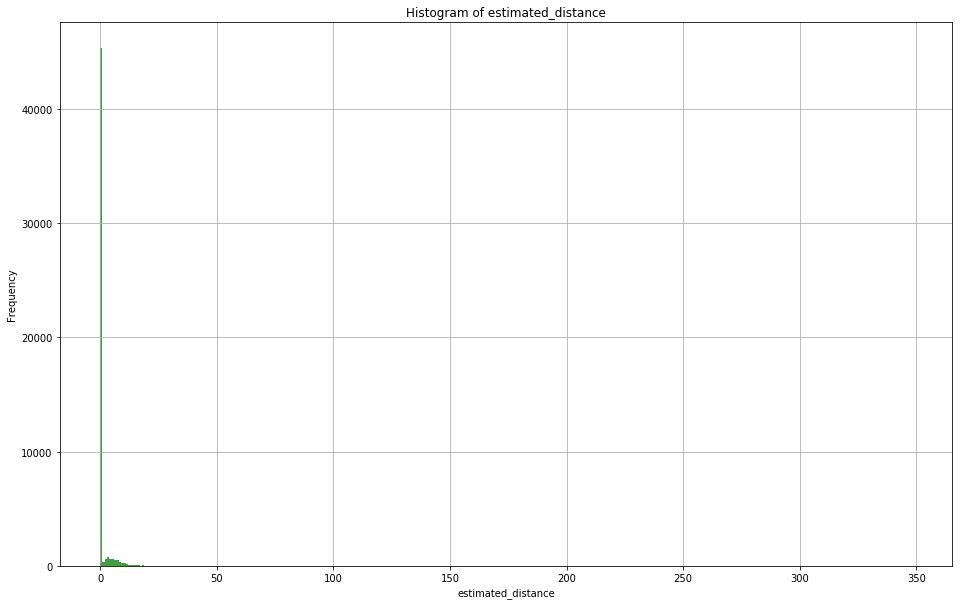

```
=================
Column : distance_travelled
=================
Number of Outliars in column distance_travelled is 37
Minimum Outliar 81.2865
Maximum Outliar 325.504
```

```
Text(0.5,0,'distance_travelled')
```

```
Text(0,0.5,'Frequency')
```

```
Text(0.5,1,'Histogram of distance_travelled')
```

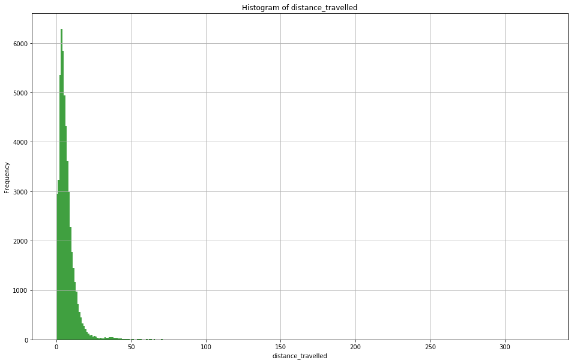

```
=================
Column : distance_travelled_while_moving
=================
Number of Outliars in column distance_travelled_while_moving is 34
Minimum Outliar 80.9075
Maximum Outliar 324.568
```

```
Text(0.5,0,'distance_travelled_while_moving')
```

```
Text(0,0.5,'Frequency')
```

```
Text(0.5,1,'Histogram of distance_travelled_while_moving')
```

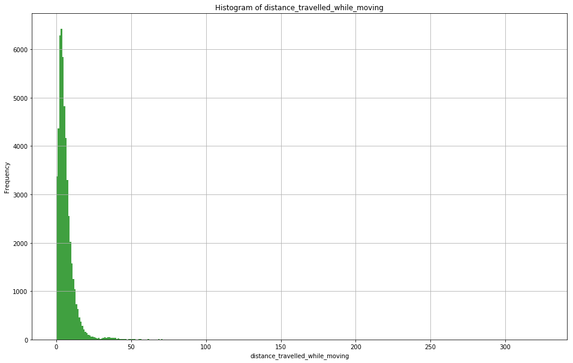

```
=================
Column : estimated_duration
=================
Number of Outliars in column estimated_duration is 26
Minimum Outliar 68
Maximum Outliar 232
```

```
Text(0.5,0,'estimated_duration')
```

```
Text(0,0.5,'Frequency')
```

```
Text(0.5,1,'Histogram of estimated_duration')
```

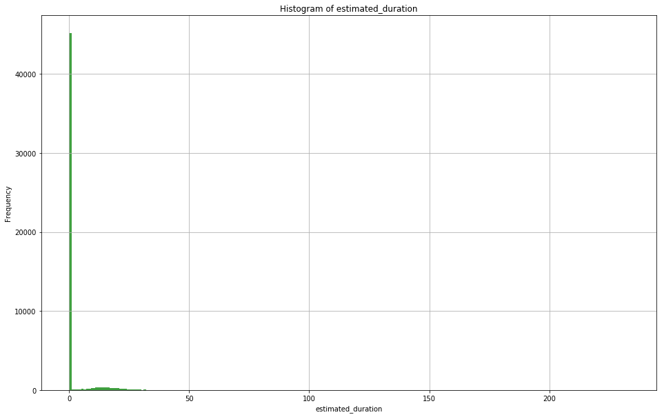

```
=================
Column : duration_time
=================
Number of Outliars in column duration_time is 36
Minimum Outliar 150
Maximum Outliar 666
```

```
Text(0.5,0,'duration_time')
```

```
Text(0,0.5,'Frequency')
```

```
Text(0.5,1,'Histogram of duration_time')
```

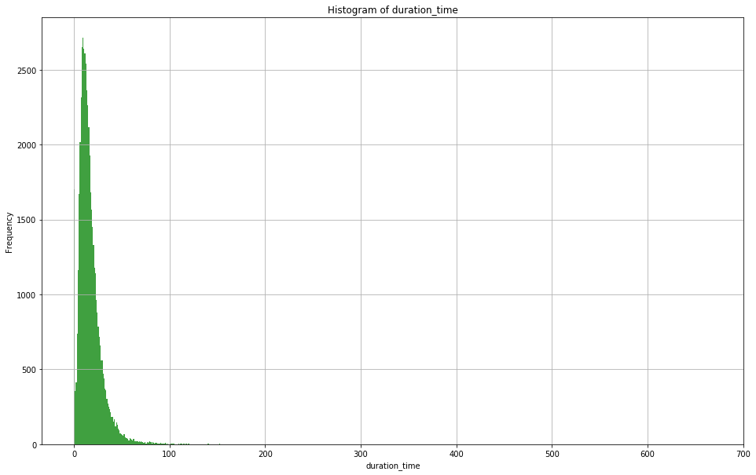

```
=================
Column : wait_time_in_journey
=================
Number of Outliars in column wait_time_in_journey is 53
Minimum Outliar 88
Maximum Outliar 524
```

```
Text(0.5,0,'wait_time_in_journey')
```

```
Text(0,0.5,'Frequency')
```

```
Text(0.5,1,'Histogram of wait_time_in_journey')
```

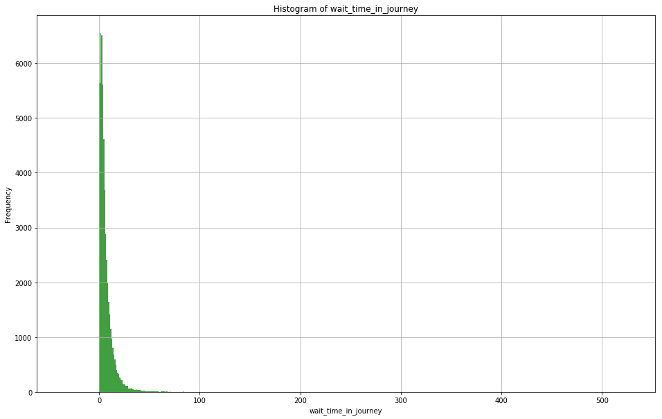

```python
cols_to_check = ['estimated_distance', 'distance_travelled', 'distance_travelled_while_moving', 'estimated_duration', 'duration_time', 'wait_time_in_journey']
# sns.boxplot(x="variable", y="value", data=pd.melt(trip_train[cols_to_check]))

outlierslist=[]
for col in cols_to_check:

    print("=================")
    print (f"Column : {col}")
    print("=================")
    col_outlier = outliers_iqr(trip_train[col])
    outlierslist.append(list(col_outlier))
    print(f'Number of Outliars in column {col} is {len(list(col_outlier)[0])}')
    #check the max and min of the outliar list
    print(f'Minimum Outliar {min(trip_train.loc[list(col_outlier)[0]][col])}' )
    print(f'Maximum Outliar {max(trip_train.loc[list(col_outlier)[0]][col])}' )

    #Plot a histogram to verify the ouliers
    fig=plt.figure(figsize=(16,10))
    #remove 0 values to view distribution of non missing values
    ax = plt.hist(trip_train[col] ,bins=range(int(trip_train[col].min()),int(trip_train[col].max()+2)), density=False, facecolor='g', alpha=0.75)
    plt.xlabel(col)
    plt.ylabel('Frequency')
    plt.title(f'Histogram of {col}')
    plt.grid(True)
    plt.show()
```

#### Understand the relationship between Distance and other features

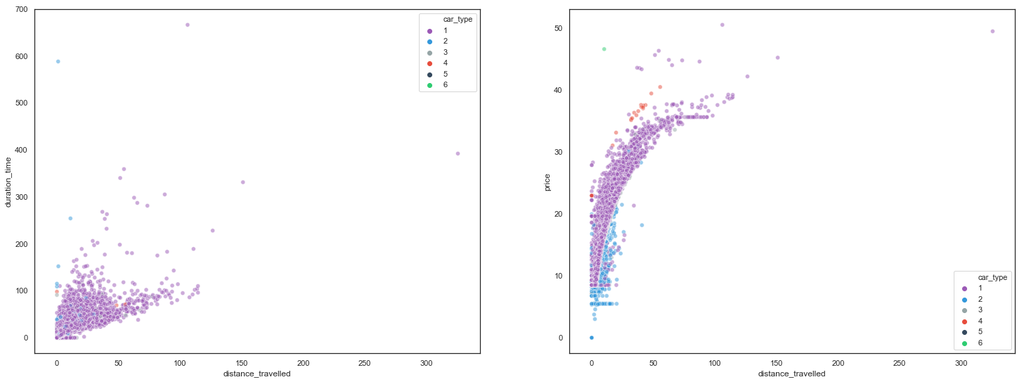

```python
sns.set(style="white", palette="muted", color_codes=True)

flatui = ["#9b59b6", "#3498db", "#95a5a6", "#e74c3c", "#34495e", "#2ecc71"]
# Set up the matplotlib figure
f, axes = plt.subplots(1, 2, figsize=(25,9), sharex=True)

#Understand the relationship between Distance travelled and time
sns.scatterplot(x="distance_travelled",palette=sns.color_palette(flatui),alpha =.5, y="duration_time",legend="full", hue="car_type",data=trip_train,ax=axes[0])

#Understand the relationship between Distance travelled and price
sns.scatterplot(x="distance_travelled",palette=sns.color_palette(flatui),alpha =.5, y="price",legend="full", hue="car_type",data=trip_train,ax=axes[1])
```

- It is obvious from the scatter plots and histograms that the selected variables are right skewed
- The technique that will be followed is removing the records with outliars values

### Remove Outliers

```python
# drop outliers from the dataframe
flat_list = [item for sublist in outlierslist for item in sublist]
records_to_drop = [item for sublist in flat_list for item in sublist]
len(records_to_drop)
records_to_drop= list(set(records_to_drop))
len(records_to_drop)
trip_train.was_rated.value_counts()
trip_train_clean= trip_train.drop(records_to_drop)
trip_train_clean.was_rated.value_counts()


# # # # execlude the records with churn_ind
# indices = trip_train.loc[records_to_drop]["was_rated"]==0
# len(indices)
# indices= indices[indices==1]
# len(indices)
# len(trip_train)
# trip_train= trip_train.drop(indices.index)
# len(trip_train)
```

```
311
```

```
214
```

```
1    34877
0    16206
Name: was_rated, dtype: int64
```

```
1    34742
0    16127
Name: was_rated, dtype: int64
```

### Identify More Data Issues

- We will assume that the wait_time_in_journey is part of the trip duration_time. therefore the wait_time_in_journey must always be less than or equals duration_time
- We will assume that any not-cancelled trips should have a valid duration_time (not 0)
- Another assumption is when the trip is_cancelled is true , the duration_time should be 0
- All time and distance should be 0 minutes/KM or more
- Let's validate those assumption and correct the issues if any

```python
# add Training and Test to a list foe easier handling
data_combined = [trip_train_clean, trip_test]
```

```python
# make sure all distance and time columns are => 0
time_dist_cols = ['estimated_distance', 'distance_travelled', 'distance_travelled_while_moving', 'estimated_duration', 'duration_time','wait_time_initial', 'wait_time_in_journey']
for dataset in data_combined:
    for col in time_dist_cols:
        dataset.loc[dataset[col] <0, col]=0
```

```python
# Validate the assumption that wait_time_in_journey must be less than duration_time
trip_train_clean[((trip_train_clean['wait_time_in_journey'] > trip_train_clean['duration_time'])| (trip_train_clean['duration_time']==0)) & (trip_train_clean['is_cancelled'] ==0)][['duration_time','wait_time_initial','wait_time_in_journey','price','is_cancelled']]
```

|  | duration_time | wait_time_initial | wait_time_in_journey | price | is_cancelled |
| --- | --- | --- | --- | --- | --- |
| 503 | 0 | 22 | 11 | 15.316173 | 0 |
| 716 | 0 | 0 | 7 | 7.069891 | 0 |
| 817 | 0 | 0 | 0 | 8.507064 | 0 |
| 878 | 0 | 0 | 0 | 10.968003 | 0 |
| 953 | 0 | 2 | 0 | 10.968003 | 0 |
| 1024 | 0 | 39 | 0 | 15.316173 | 0 |
| 1084 | 0 | 0 | 0 | 8.507064 | 0 |
| 1092 | 0 | 0 | 0 | 10.968003 | 0 |
| 1100 | 0 | 0 | 0 | 10.968003 | 0 |
| 1263 | 0 | 0 | 13 | 10.968003 | 0 |
| 1440 | 0 | 0 | 0 | 8.507064 | 0 |
| 1717 | 0 | 8 | 0 | 10.968003 | 0 |
| 1832 | 0 | 0 | 0 | 10.968003 | 0 |
| 1896 | 0 | 0 | 0 | 10.968003 | 0 |
| 2152 | 0 | 0 | 3 | 8.507064 | 0 |
| 2308 | 0 | 0 | 18 | 13.086745 | 0 |
| 2404 | 0 | 0 | 27 | 12.807851 | 0 |
| 2507 | 0 | 0 | 0 | 8.507064 | 0 |
| 2556 | 0 | 0 | 0 | 10.968003 | 0 |
| 2565 | 0 | 1 | 0 | 8.507064 | 0 |
| 2872 | 0 | 10 | 0 | 8.507064 | 0 |
| 2941 | 0 | 0 | 0 | 8.507064 | 0 |
| 3084 | 0 | 0 | 0 | 10.968003 | 0 |
| 3524 | 0 | 1 | 0 | 7.069891 | 0 |
| 3639 | 0 | 0 | 2 | 10.968003 | 0 |
| 3997 | 0 | 0 | 0 | 10.968003 | 0 |
| 4204 | 0 | 0 | 4 | 10.968003 | 0 |
| 4819 | 0 | 0 | 0 | 10.968003 | 0 |
| 4909 | 0 | 0 | 0 | 8.507064 | 0 |
| 5074 | 1 | 0 | 2 | 10.968003 | 0 |
| ... | ... | ... | ... | ... | ... |
| 45119 | 0 | 0 | 0 | 8.507064 | 0 |
| 45194 | 0 | 0 | 0 | 8.507064 | 0 |
| 45263 | 0 | 1 | 0 | 8.507064 | 0 |
| 45743 | 0 | 0 | 0 | 8.507064 | 0 |
| 45969 | 0 | 0 | 0 | 8.507064 | 0 |
| 46151 | 0 | 0 | 0 | 9.299303 | 0 |
| 46397 | 0 | 0 | 0 | 8.507064 | 0 |
| 46619 | 0 | 0 | 0 | 8.507064 | 0 |
| 46625 | 0 | 0 | 0 | 8.507064 | 0 |
| 46658 | 0 | 0 | 7 | 12.227772 | 0 |
| 46690 | 0 | 0 | 0 | 9.203343 | 0 |
| 46816 | 0 | 0 | 0 | 8.507064 | 0 |
| 46972 | 0 | 0 | 0 | 8.507064 | 0 |
| 47770 | 0 | 0 | 0 | 8.507064 | 0 |
| 47939 | 0 | 0 | 0 | 8.507064 | 0 |
| 48016 | 0 | 4 | 0 | 8.507064 | 0 |
| 48219 | 0 | 0 | 0 | 8.507064 | 0 |
| 48221 | 0 | 0 | 0 | 10.968003 | 0 |
| 48304 | 0 | 0 | 0 | 8.507064 | 0 |
| 48324 | 0 | 0 | 3 | 10.968003 | 0 |
| 48674 | 0 | 0 | 0 | 8.507064 | 0 |
| 49003 | 0 | 12 | 0 | 7.425686 | 0 |
| 49056 | 0 | 1 | 0 | 8.507064 | 0 |
| 49306 | 0 | 0 | 0 | 8.507064 | 0 |
| 49661 | 0 | 23 | 0 | 11.644130 | 0 |
| 49673 | 0 | 3 | 0 | 8.507064 | 0 |
| 49707 | 0 | 0 | 0 | 8.507064 | 0 |
| 49776 | 0 | 0 | 0 | 5.479478 | 0 |
| 50697 | 0 | 0 | 4 | 11.925872 | 0 |
| 50914 | 0 | 0 | 0 | 8.507064 | 0 |

219 rows × 5 columns

- Apparently, some data issues exist and need to be fixed

```python
# Create new temp column for duration_time
for dataset in data_combined:
    dataset['duration_time_new']=dataset['duration_time']
```

```python
# prepare a mapping dataset for duration_time based on price and wait_time_in_journey columns
correct_trips = trip_train_clean[((trip_train_clean['wait_time_in_journey'] < trip_train_clean['duration_time'])& (trip_train_clean['duration_time']!=0)) & (trip_train_clean['is_cancelled'] ==0)][['duration_time','wait_time_in_journey','price']]
correct_trips['price']=correct_trips['price'].astype(int)
temp_avg_time = correct_trips.groupby(['price','wait_time_in_journey']).mean().rename(columns={'duration_time':'avg_duration_time'}).reset_index()
temp_avg_time
```

|  | price | wait_time_in_journey | avg_duration_time |
| --- | --- | --- | --- |
| 0 | 3 | 0 | 4.000000 |
| 1 | 3 | 1 | 5.000000 |
| 2 | 4 | 6 | 11.000000 |
| 3 | 5 | 0 | 33.600000 |
| 4 | 5 | 1 | 9.600000 |
| 5 | 5 | 2 | 10.333333 |
| 6 | 5 | 3 | 15.833333 |
| 7 | 5 | 4 | 18.625000 |
| 8 | 5 | 5 | 14.857143 |
| 9 | 5 | 6 | 18.111111 |
| 10 | 5 | 7 | 16.500000 |
| 11 | 5 | 8 | 18.400000 |
| 12 | 5 | 9 | 22.500000 |
| 13 | 5 | 10 | 25.000000 |
| 14 | 5 | 11 | 26.000000 |
| 15 | 5 | 12 | 24.500000 |
| 16 | 5 | 13 | 32.333333 |
| 17 | 5 | 14 | 37.500000 |
| 18 | 5 | 15 | 32.750000 |
| 19 | 5 | 16 | 26.000000 |
| 20 | 5 | 17 | 34.000000 |
| 21 | 5 | 18 | 37.000000 |
| 22 | 5 | 19 | 36.000000 |
| 23 | 5 | 26 | 48.000000 |
| 24 | 5 | 27 | 48.000000 |
| 25 | 5 | 28 | 56.000000 |
| 26 | 5 | 29 | 49.500000 |
| 27 | 5 | 33 | 53.000000 |
| 28 | 5 | 36 | 58.000000 |
| 29 | 6 | 0 | 3.666667 |
| ... | ... | ... | ... |
| 1061 | 34 | 33 | 85.000000 |
| 1062 | 34 | 40 | 114.000000 |
| 1063 | 34 | 46 | 95.000000 |
| 1064 | 35 | 3 | 32.000000 |
| 1065 | 35 | 4 | 68.000000 |
| 1066 | 35 | 5 | 57.750000 |
| 1067 | 35 | 7 | 56.000000 |
| 1068 | 35 | 8 | 62.333333 |
| 1069 | 35 | 9 | 48.000000 |
| 1070 | 35 | 10 | 61.000000 |
| 1071 | 35 | 11 | 78.000000 |
| 1072 | 35 | 13 | 82.000000 |
| 1073 | 35 | 15 | 74.000000 |
| 1074 | 35 | 18 | 78.000000 |
| 1075 | 35 | 19 | 84.000000 |
| 1076 | 35 | 20 | 94.000000 |
| 1077 | 35 | 21 | 89.000000 |
| 1078 | 35 | 31 | 92.000000 |
| 1079 | 35 | 39 | 90.000000 |
| 1080 | 35 | 40 | 102.000000 |
| 1081 | 36 | 1 | 35.000000 |
| 1082 | 36 | 11 | 69.000000 |
| 1083 | 36 | 13 | 58.000000 |
| 1084 | 37 | 2 | 49.500000 |
| 1085 | 37 | 7 | 63.000000 |
| 1086 | 37 | 9 | 52.000000 |
| 1087 | 37 | 14 | 48.000000 |
| 1088 | 37 | 16 | 79.000000 |
| 1089 | 38 | 13 | 71.000000 |
| 1090 | 46 | 5 | 18.000000 |

1091 rows × 3 columns

```python
# prepare a function to be called with each row withincorrect duration_time in training and test to fix the dara issue if exist
def get_duration_time_median(price, wait_time_in_journey):
   return int(temp_avg_time[(temp_avg_time['price'] >= price-2) & (temp_avg_time['price'] < price+2) \
                             & (temp_avg_time['wait_time_in_journey'] >= wait_time_in_journey-2)\
                            & (temp_avg_time['wait_time_in_journey'] <  wait_time_in_journey+2)]['avg_duration_time'].mean())
```

```python
# Apply the fix, fill in the incorrect duration_time with mean of duration time of other trips with similar price +-2 and similar  wait_time_in_journey +-2
for dataset in data_combined:
    dataset.loc[((dataset['wait_time_in_journey'] > dataset['duration_time'])| (dataset['duration_time']==0)) & (dataset['is_cancelled'] ==0),'duration_time_new']=\
    dataset[((dataset['wait_time_in_journey'] > dataset['duration_time'])| (dataset['duration_time']==0)) & (dataset['is_cancelled'] ==0) ].apply(lambda row: get_duration_time_median(row['price'],row['wait_time_in_journey']), axis=1)
```

```python
for dataset in data_combined:
    dataset['duration_time_new']=dataset['duration_time_new'].astype(int)
```

```python
# check the results after applying the fix
trip_train_clean[(trip_train_clean['wait_time_in_journey'] > trip_train_clean['duration_time']) & (trip_train_clean['is_cancelled'] ==0) ][['duration_time','duration_time_new','wait_time_initial','wait_time_in_journey','price','is_cancelled']]
```

|  | duration_time | duration_time_new | wait_time_initial | wait_time_in_journey | price | is_cancelled |
| --- | --- | --- | --- | --- | --- | --- |
| 503 | 0 | 23 | 22 | 11 | 15.316173 | 0 |
| 716 | 0 | 12 | 0 | 7 | 7.069891 | 0 |
| 1263 | 0 | 18 | 0 | 13 | 10.968003 | 0 |
| 2152 | 0 | 8 | 0 | 3 | 8.507064 | 0 |
| 2308 | 0 | 24 | 0 | 18 | 13.086745 | 0 |
| 2404 | 0 | 28 | 0 | 27 | 12.807851 | 0 |
| 3639 | 0 | 8 | 0 | 2 | 10.968003 | 0 |
| 4204 | 0 | 10 | 0 | 4 | 10.968003 | 0 |
| 5074 | 1 | 8 | 0 | 2 | 10.968003 | 0 |
| 5187 | 0 | 10 | 0 | 4 | 10.968003 | 0 |
| 5342 | 0 | 17 | 0 | 9 | 12.963686 | 0 |
| 5556 | 0 | 9 | 0 | 3 | 10.968003 | 0 |
| 6647 | 0 | 8 | 0 | 3 | 8.507064 | 0 |
| 6712 | 0 | 9 | 0 | 3 | 10.968003 | 0 |
| 6831 | 0 | 10 | 0 | 4 | 10.968003 | 0 |
| 7063 | 1 | 8 | 0 | 3 | 8.507064 | 0 |
| 7381 | 0 | 27 | 0 | 17 | 15.316173 | 0 |
| 7505 | 0 | 15 | 0 | 10 | 10.968003 | 0 |
| 8915 | 3 | 14 | 6 | 8 | 10.968003 | 0 |
| 10801 | 0 | 8 | 0 | 2 | 10.968003 | 0 |
| 13394 | 0 | 10 | 0 | 4 | 10.968003 | 0 |
| 13402 | 0 | 9 | 0 | 3 | 10.968003 | 0 |
| 13564 | 0 | 26 | 0 | 19 | 10.968003 | 0 |
| 14303 | 0 | 14 | 0 | 8 | 10.968003 | 0 |
| 14362 | 0 | 20 | 0 | 12 | 13.882732 | 0 |
| 16333 | 0 | 18 | 0 | 14 | 10.968003 | 0 |
| 16563 | 0 | 11 | 0 | 6 | 8.507064 | 0 |
| 18537 | 0 | 14 | 0 | 8 | 10.968003 | 0 |
| 19160 | 0 | 8 | 0 | 2 | 10.968003 | 0 |
| 19953 | 0 | 24 | 0 | 17 | 13.991198 | 0 |
| 20336 | 0 | 26 | 0 | 16 | 15.316173 | 0 |
| 22815 | 0 | 18 | 0 | 7 | 14.382364 | 0 |
| 24587 | 0 | 7 | 0 | 2 | 8.507064 | 0 |
| 24610 | 0 | 10 | 0 | 4 | 10.968003 | 0 |
| 24927 | 0 | 15 | 0 | 11 | 9.127560 | 0 |
| 25415 | 0 | 8 | 0 | 1 | 10.968003 | 0 |
| 25962 | 0 | 15 | 0 | 5 | 13.358653 | 0 |
| 27396 | 1 | 18 | 0 | 13 | 10.629890 | 0 |
| 27552 | 0 | 7 | 0 | 2 | 8.776727 | 0 |
| 27768 | 0 | 6 | 0 | 1 | 8.507064 | 0 |
| 29563 | 0 | 7 | 0 | 2 | 8.507064 | 0 |
| 29663 | 0 | 11 | 0 | 6 | 8.507064 | 0 |
| 32946 | 0 | 13 | 0 | 9 | 8.507064 | 0 |
| 33929 | 0 | 10 | 0 | 5 | 8.507064 | 0 |
| 35674 | 8 | 13 | 5 | 9 | 8.507064 | 0 |
| 36745 | 0 | 6 | 0 | 1 | 8.507064 | 0 |
| 36982 | 0 | 7 | 0 | 2 | 8.507064 | 0 |
| 43055 | 0 | 10 | 0 | 5 | 8.507064 | 0 |
| 43123 | 0 | 11 | 0 | 4 | 11.925872 | 0 |
| 43470 | 0 | 11 | 0 | 4 | 11.296407 | 0 |
| 46658 | 0 | 15 | 0 | 7 | 12.227772 | 0 |
| 48324 | 0 | 9 | 0 | 3 | 10.968003 | 0 |
| 50697 | 0 | 11 | 0 | 4 | 11.925872 | 0 |

- Now duration_time_new looks better and always the wait_time_in_journey is less than duration_time

```python
# drop the exisitg column duration_time then rename the new column to duration_time
for dataset in data_combined:
    dataset.drop(columns = ['duration_time'], inplace=True, index=1)
    dataset.rename(columns={'duration_time_new':'duration_time'}, inplace=True)
```

```python
dataset.columns
```

```
Index(['customer_id', 'driver_id', 'creation_date', 'booking_source',
       'car_type', 'estimated_distance', 'distance_travelled',
       'distance_travelled_while_moving', 'estimated_duration',
       'wait_time_initial', 'wait_time_in_journey', 'estimated_price', 'price',
       'is_cancelled', 'duration_time'],
      dtype='object')
```

```python
trip_train_clean[(trip_train_clean['duration_time']==0) & (trip_train_clean['is_cancelled']==0)]
```

|  | customer_id | driver_id | creation_date | booking_source | car_type | estimated_distance | distance_travelled | distance_travelled_while_moving | estimated_duration | wait_time_initial | wait_time_in_journey | estimated_price | price | is_cancelled | rating | was_rated | duration_time |
| --- | --- | --- | --- | --- | --- | --- | --- | --- | --- | --- | --- | --- | --- | --- | --- | --- | --- |

- Now all non-cancelled trips has a valid duration_time

### Understand the relationship between selected columns (Distance and Time) after removing outliers and fixing data issues

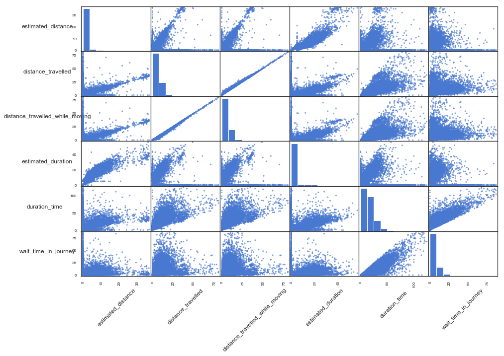

```python
axs = scatter_matrix(trip_train_clean[cols_to_check], alpha=0.7, figsize=(15, 10), diagonal='hist')
n = len(cols_to_check)
for x in range(n):
    for y in range(n):
        # to get the axis of subplots
        ax = axs[x, y]
        # to make x axis name vertical
        ax.xaxis.label.set_rotation(45)
        # to make y axis name horizontal
        ax.yaxis.label.set_rotation(0)
        # to make sure y axis names are outside the plot area
        ax.yaxis.labelpad = 50
```

```python
# Correct negative numbers in wait_time_in_journey
trip_train_clean.loc[trip_train_clean['wait_time_in_journey'] <0, 'wait_time_in_journey'] =0
```

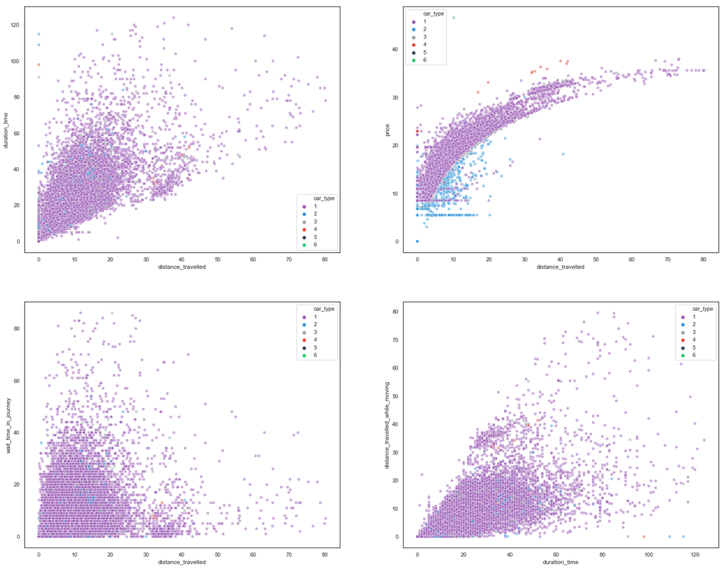

```python
# Redraw the same scatter plots to check the data after cleaning
flatui = ["#9b59b6", "#3498db", "#95a5a6", "#e74c3c", "#34495e", "#2ecc71"]
sns.set(style="white", palette="muted", color_codes=True)
# Set up the matplotlib figure
f, axes = plt.subplots(2, 2, figsize=(25,20), sharex=False)

#Understand the relation ship between Distance travelled and time
sns.scatterplot(x="distance_travelled", y="duration_time",palette=sns.color_palette(flatui),alpha =.5,legend="full", hue="car_type",data=trip_train_clean,ax=axes[0,0])


#Understand the relation ship between Distance travelled and price
sns.scatterplot(x="distance_travelled",palette=sns.color_palette(flatui),alpha =.5, y="price",legend="full", hue="car_type",data=trip_train_clean,ax=axes[0,1])


#Understand the relation ship between Distance travelled and wait_time_in_journey
sns.scatterplot(x="distance_travelled",palette=sns.color_palette(flatui),alpha =.5, y="wait_time_in_journey",legend="full", hue="car_type",data=trip_train_clean,ax=axes[1,0])

#Understand the relation ship between Duration time and distance_travelled_while_moving
sns.scatterplot(x="duration_time",palette=sns.color_palette(flatui),alpha =.5, y="distance_travelled_while_moving",legend="full", hue="car_type",data=trip_train_clean,ax=axes[1,1])
```

##### Quick Observation

- The relationship between variables are now more clear. it is linear relationship with some exceptions
- Rides in Car type 4 is the most expensive rides and one of the fastest rides
- Car Type 2 has average [capped] lower cost compared to Car Type 1 and apparently has a limited distance trips.

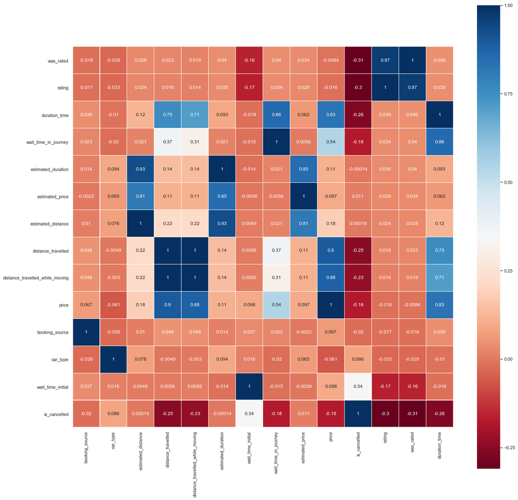

```python
# Check columns correclations
cols_corr = [ 'booking_source','car_type', 'estimated_distance', 'distance_travelled',
       'distance_travelled_while_moving', 'estimated_duration','wait_time_initial', 'wait_time_in_journey', 'estimated_price', 'price',
       'is_cancelled', 'rating', 'was_rated', 'duration_time']

trip_train_clean_temp = trip_train_clean.copy()


colormap = plt.cm.RdBu


#print(i)
sns.set_style("whitegrid")

a4_dims = (len(cols_corr)*1.5,len(cols_corr)*1.5)
fig, ax = plt.subplots(figsize=a4_dims)
sns_plot =sns.heatmap(trip_train_clean_temp[cols_corr].astype(float).corr().sort_values('was_rated' , ascending = False),linewidths=0.5,vmax=1.0,
            square=True, cmap=colormap, linecolor='white', annot=True, ax=ax)
```

## 3- Features Generation

- Extract features for Training & Test datasets from existing columns
- Adjust existing feature for better utilization
- create a feature for missing values
- avpid filling NaNs before feature generations
- Rated last trip
- rated_trips_count
- lst_mnth_trip_cnt
- avg_rating , - average rating , - rating count - indicator - for driver - for customer
- request a trip price =1 if estimated_price is not empty

```python
def rated_only_count(x):
    rated_count = x[x != 0].count()
    return  rated_count

def rated_only_mean(x):
    rated_mean=x[x != 0].mean()
    return  rated_mean
summary_set = []
for col in ['driver_id','customer_id']:
    rate_smry = trip_train_clean[[col,'was_rated','rating']].groupby([col]).agg({'was_rated':'count','rating':[rated_only_count,rated_only_mean,'mean']}).reset_index()
    rate_smry.columns= [col, col+'_'+'trip_count', col+'_'+'rated_trip_count',col+'_'+'rated_trip_avg',col+'_'+'all_trip_rate_avg']
#     rate_smry

    #summary_old= trip_rating[[col,'rating']].groupby([col]).agg({'rating':['count','mean']}).reset_index()
    summary_old = trip_rating[[col,'rating']].groupby([col]).agg({'rating':['count',rated_only_count,rated_only_mean,'mean']}).reset_index()
    summary_old.columns =[col, col+'_'+'lst_mnth_trip_count', col+'_'+'lst_mnth_rated_trip_count',col+'_'+'lst_mnth_rated_trip_avg',col+'_'+'lst_mnth_all_trip_rate_avg']
#     summary_old

    col_summary=rate_smry.merge(summary_old, on=[col] , how='left')
#     col_summary
    summary_set.append(col_summary)
```

```python
driver_summary = summary_set[0]
customer_summary = summary_set[1]
```

```python
#Attach Driver Stats with train and test datasets
trip_train_clean_jnd = trip_train_clean.merge(driver_summary, how='left', on ='driver_id')
trip_test_jnd = trip_test.merge(driver_summary, how='left', on ='driver_id')
```

```python
data_combined = [trip_train_clean_jnd,trip_test_jnd]
```

```python
(calendar.weekday(2014, 1, 19) + 1) % 7
```

```
0
```

```python
# Duration in Hours
for dataset in data_combined:
    dataset['creation_date'] = pd.to_datetime(dataset['creation_date'])
    #Generate Trip duration in hours feature
    dataset['duration_time_hours'] = dataset['duration_time']/60

    #Generate Trip time feature

    dataset['trip_month']=dataset['creation_date'].dt.month

    dataset['trip_time']=dataset['creation_date'].apply(timeOfDay,1)

    dataset['trip_hour']=dataset['creation_date'].dt.hour

    dataset['trip_day']=dataset['creation_date'].dt.day

    # Extract Speed (KM/Hour) from time and Distance
    dataset['speed'] = dataset['distance_travelled']/dataset['duration_time_hours']
```

```python
# correct the speed for trips with speed > 150 KM/H
max_norm_speed = trip_train_clean_jnd[trip_train_clean_jnd['speed'] <150]['speed'].max()
max_norm_speed
for dataset in data_combined:
    dataset.loc[dataset['speed']> 150,'speed'] = max_norm_speed
    dataset = ConvertSpeed(dataset,'speed')
```

```
147.288
```

#### Check the trip distribution to detect the weekends vs weekdays

```
Text(0.5,0,'trip_day')
```

```
Text(0,0.5,'Frequency')
```

```
Text(0.5,1,'Histogram of trip_day')
```

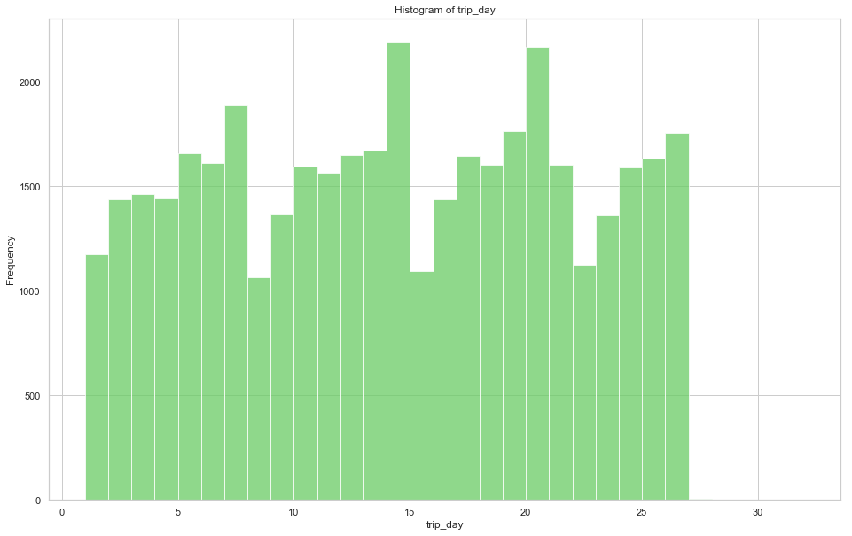

```python
fig=plt.figure(figsize=(16,10))
#remove 0 values to view distribution of non missing values
ax = plt.hist(trip_train_clean_jnd[trip_train_clean_jnd['trip_month']==9]['trip_day'] ,bins=range(int(trip_train_clean_jnd['trip_day'].min()),int(trip_train_clean_jnd['trip_day'].max()+2)), density=False, facecolor='g', alpha=0.75)
plt.xlabel('trip_day')
plt.ylabel('Frequency')
plt.title(f'Histogram of trip_day')
plt.grid(True)
plt.show()
```

#### Quick Observation

- A trip count pattern can be easily identified with lowest trips on Days 8, 15, 22nd, those days are Fridays.
- Since we don't know the city, and based on the above graph , we will assume that the weekends are Fridays and Saturdays
- Working days are Sunday to Thursday

```python
#Generate the Weekday (Sunday =1 to Saturday=7)
for dataset in data_combined:
    dataset['trip_weekday']=(dataset['creation_date'].dt.weekday+1)%7+1
    dataset['during_working_hours']=0
    dataset['trip_isweekend']=0
    dataset['trip_islunchtime']=0
    dataset.loc[((dataset['trip_weekday'] <6) & (dataset['trip_hour'] >=8) & (dataset['trip_hour'] <19)), 'during_working_hours']=1
    dataset.loc[(dataset['trip_weekday'] >=6) , 'trip_isweekend']=1
    dataset.loc[((dataset['trip_weekday'] <6) & (dataset['trip_hour'] >=11) & (dataset['trip_hour'] <14)), 'trip_islunchtime']=1
```

## 4- Assignment Questions

### Question 1: Help us to understand our data!

We want you to get a bit deeper in our business process. To be frank we need your help! We have some ideas:

1. We think, the higher a captain’s average speed the higher his/her rating. We think customers like speedy rides!
2. Our customers can request a trip price estimation by putting the destination address but it’s not required. If a customer requests the price estimation, estimated_price column isn’t empty and contains the price our algorithms predict for the trip. We suppose, there is a dependence: customers are more likely to request a trip price if they are going far.

Can you check it out for us and explain the dependencies? If you have a couple of ideas how to check and prove - go ahead, we would like to listen all of them!

#### Plot Overall Speed/Hight Rating relationship

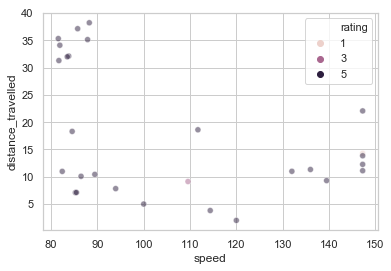

```python
flatui5 = ["#9b59b6", "#3498db", "#95a5a6", "#34495e","#e74c3c"]
#We assume that speedy driver are those who drvie more than 80KM/H
speedy_drivers = trip_train_clean_jnd[(trip_train_clean_jnd['speed']> 80 ) & (trip_train_clean_jnd['rating']!= 0)]
sns.scatterplot(x="speed", y="distance_travelled",alpha =.5,legend="full", hue="rating",data=speedy_drivers)
```

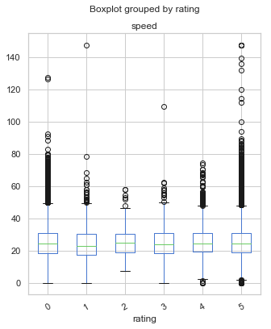

```python
trip_train_clean_jnd.boxplot('speed','rating',rot = 30,figsize=(5,6))
```

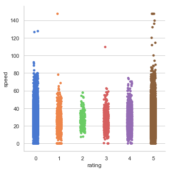

```python
# Another Plot
sns.catplot(x="rating", y="speed", data=trip_train_clean_jnd)
```

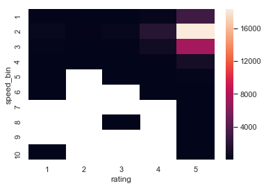

```python
captain_speed = trip_train_clean_jnd[trip_train_clean_jnd['rating']>0][['speed_bin','rating','driver_id']].groupby(['speed_bin','rating']).count().rename(columns={'driver_id':'trip_count'}).reset_index()
captain_speed_piv = captain_speed.pivot("speed_bin", "rating", "trip_count")
ax = sns.heatmap(captain_speed_piv)
```

```python
trip_train_clean_jnd.groupby(['speed_bin'])['rating'].mean()
```

```
speed_bin
1     3.005030
2     3.438937
3     3.368211
4     3.286701
5     2.756667
6     3.117647
7     2.500000
8     4.333333
9     2.500000
10    4.428571
Name: rating, dtype: float64
```

- It is clear from above plots that there is no linear relationship between the captain's speed and the rating, however the trips with speed higher that 80 KM/H got rating 5 in all cases (with some exceptions)
- let's prove the assumption using statistical correclation

```python
corr_col = ['booking_source',
       'car_type', 'estimated_distance', 'distance_travelled',
       'distance_travelled_while_moving', 'estimated_duration',
       'wait_time_initial', 'wait_time_in_journey', 'estimated_price', 'price',
       'is_cancelled', 'duration_time',
       'driver_id_trip_count', 'driver_id_rated_trip_count',
       'driver_id_rated_trip_avg', 'driver_id_all_trip_rate_avg',
       'driver_id_lst_mnth_trip_count', 'driver_id_lst_mnth_rated_trip_count',
       'driver_id_lst_mnth_rated_trip_avg',
       'driver_id_lst_mnth_all_trip_rate_avg', 'duration_time_hours',
       'trip_month', 'trip_time', 'trip_hour', 'trip_day', 'speed',
       'speed_bin', 'trip_weekday', 'during_working_hours', 'trip_isweekend','trip_islunchtime','rating']
#Check correclation between all the features and 'rating' and 'was_rated'
trip_train_clean_jnd[corr_col].corr()['rating'][:].sort_values()
```

```
is_cancelled                           -0.300570
wait_time_initial                      -0.166007
car_type                               -0.033113
during_working_hours                   -0.032270
trip_hour                              -0.023214
trip_islunchtime                       -0.021838
booking_source                         -0.016977
price                                  -0.015502
trip_day                               -0.007072
trip_weekday                           -0.002518
driver_id_lst_mnth_trip_count           0.006151
trip_isweekend                          0.006403
driver_id_lst_mnth_rated_trip_count     0.013085
distance_travelled_while_moving         0.014443
driver_id_lst_mnth_rated_trip_avg       0.015064
driver_id_trip_count                    0.017640
distance_travelled                      0.017859
driver_id_lst_mnth_all_trip_rate_avg    0.018302
trip_month                              0.018801
estimated_distance                      0.024070
speed                                   0.026787
estimated_price                         0.028203
wait_time_in_journey                    0.034195
estimated_duration                      0.035393
duration_time                           0.039166
duration_time_hours                     0.039166
driver_id_rated_trip_avg                0.087105
driver_id_rated_trip_count              0.096055
driver_id_all_trip_rate_avg             0.347352
rating                                  1.000000
Name: rating, dtype: float64
```

### Question 2: Skipped based on the requirments

### 3. Rating prediction

- In order to give the best possible service, we want to understand our customers better. We really like feedbacks and to improve the interaction with our customers we need a model to predict if they will rate a trip.
- You are given training (the one you already know well) and testing datasets. Using this datasets, build a model to predict if the trip was rated. ( was_rated column)
- Moreover, in order to help you to gather some additional customer’s information, to look at their personal rating history, we prepared some additional dataset trip rating dataset from the previous 30-days period (30 days before the training dataset collected): customer_id, driver_id, rating, was_rated
- Describe the model, feature engineering, parameter and feature selection process and recommend us a metric to estimate your work. Send us your code and prediction file for the testing dataset in csv format: entry_id, was_rated

Don’t forget, we really appreciate comments

#### Solution:

- First Prepare feature for model building. standardize and one-hot encoding process.
- Use the features generated in previous section along with original features in the modeling
- Try different algorithms

#### Standardize numeric values

```python
#Use MinMax scaler
for dataset in data_combined:
    #Normalize other columns
    colnorm = [ 'estimated_distance', 'distance_travelled',
       'distance_travelled_while_moving', 'estimated_duration',
       'wait_time_initial', 'wait_time_in_journey', 'estimated_price', 'price',
        'duration_time', 'driver_id_trip_count',
       'driver_id_rated_trip_count', 'driver_id_rated_trip_avg',
       'driver_id_all_trip_rate_avg', 'driver_id_lst_mnth_trip_count',
       'driver_id_lst_mnth_rated_trip_count',
       'driver_id_lst_mnth_rated_trip_avg',
       'driver_id_lst_mnth_all_trip_rate_avg', 'duration_time_hours', 'speed']
    for col in colnorm:
        dataset[col]=dataset[col].astype(float)
        dataset[col] = dataset[col].fillna(dataset[col].mean())
        min_max_scaler = preprocessing.MinMaxScaler()
        x_scaled = min_max_scaler.fit(dataset[[col]])
        dataset[col] = x_scaled.transform(dataset[[col]])
```

#### Use One-hot encoding for categorical variables

```python
# one-hot encoding for category features
cat_cols = ['booking_source','car_type', 'trip_month', 'trip_time', 'trip_hour', 'trip_day',
       'speed_bin', 'trip_weekday']
trip_train_clean_jnd = OneHotEncoderfunc(trip_train_clean_jnd, cat_cols)
trip_train_clean_jnd= trip_train_clean_jnd.loc[:, (trip_train_clean_jnd == 0).sum() < len(trip_train_clean_jnd) *(99.975/100)]
```

```
Before : (50868, 36)
After : (50868, 115)
```

#### Prepare dataset for training

```python
trip_train_clean_jnd.columns = [x.lower() for x in trip_train_clean_jnd.columns]
trip_train_clean_jnd.reset_index(drop=True )

train_x = trip_train_clean_jnd.drop(['rating','was_rated','customer_id', 'driver_id', 'creation_date'],axis=1)
train_y = trip_train_clean_jnd['was_rated']
```

|  | customer_id | driver_id | creation_date | estimated_distance | distance_travelled | distance_travelled_while_moving | estimated_duration | wait_time_initial | wait_time_in_journey | estimated_price | price | is_cancelled | rating | was_rated | duration_time | driver_id_trip_count | driver_id_rated_trip_count | driver_id_rated_trip_avg | driver_id_all_trip_rate_avg | driver_id_lst_mnth_trip_count | driver_id_lst_mnth_rated_trip_count | driver_id_lst_mnth_rated_trip_avg | driver_id_lst_mnth_all_trip_rate_avg | duration_time_hours | trip_month | speed | during_working_hours | trip_isweekend | trip_islunchtime | … |
| --- | --- | --- | --- | --- | --- | --- | --- | --- | --- | --- | --- | --- | --- | --- | --- | --- | --- | --- | --- | --- | --- | --- | --- | --- | --- | --- | --- | --- | --- | --- |
| 0 | 52400320 | 1838640 | 2017-09-08 11:32:05 | 0.000000 | 0.090827 | 0.090152 | 0.000000 | 0.246575 | 0.023256 | 0.000000 | 0.372693 | 0 | 4 | 1 | 0.088710 | 0.078431 | 0.051282 | 0.875000 | 0.360000 | 0.050847 | 0.047619 | 1.000000 | 0.500000 | 0.088710 | 9 | 0.269848 | 0 | 1 | 0 | … |
| 1 | 30828968 | 1726788 | 2017-09-08 12:46:42 | 0.000000 | 0.181714 | 0.181390 | 0.000000 | 0.041096 | 0.023256 | 0.000000 | 0.423529 | 0 | 5 | 1 | 0.129032 | 0.078431 | 0.076923 | 1.000000 | 0.600000 | 0.067797 | 0.071429 | 0.916667 | 0.560000 | 0.129032 | 9 | 0.371166 | 0 | 1 | 0 | … |
| 2 | 47974768 | 1181696 | 2017-09-08 13:52:35 | 0.000000 | 0.018935 | 0.014908 | 0.000000 | 0.000000 | 0.058140 | 0.000000 | 0.235261 | 0 | 0 | 0 | 0.064516 | 0.588235 | 0.538462 | 0.916667 | 0.632258 | 0.220339 | 0.238095 | 0.950000 | 0.685714 | 0.064516 | 9 | 0.077354 | 0 | 1 | 0 | … |
| 3 | 59503764 | 2063752 | 2017-09-08 14:18:47 | 0.000000 | 0.138274 | 0.134057 | 0.000000 | 0.013699 | 0.046512 | 0.000000 | 0.377416 | 0 | 5 | 1 | 0.153226 | 0.235294 | 0.179487 | 1.000000 | 0.538462 | 0.232160 | 0.246420 | 0.946953 | 0.672955 | 0.153226 | 9 | 0.237841 | 0 | 1 | 0 | … |
| 4 | 57190176 | 650924 | 2017-09-08 14:41:22 | 0.000000 | 0.078749 | 0.068577 | 0.000000 | 0.027397 | 0.081395 | 0.000000 | 0.293360 | 0 | 0 | 0 | 0.129032 | 0.176471 | 0.153846 | 0.958333 | 0.580000 | 0.220339 | 0.166667 | 0.964286 | 0.485714 | 0.129032 | 9 | 0.160851 | 0 | 1 | 0 | … |
| 5 | 12257432 | 1308432 | 2017-09-08 15:32:02 | 0.000000 | 0.050317 | 0.047516 | 0.000000 | 0.041096 | 0.034884 | 0.000000 | 0.235261 | 0 | 0 | 0 | 0.080645 | 0.078431 | 0.051282 | 1.000000 | 0.400000 | 0.135593 | 0.214286 | 1.000000 | 1.000000 | 0.080645 | 9 | 0.164441 | 0 | 1 | 0 | … |
| 6 | 55498260 | 2020484 | 2017-09-08 15:39:12 | 0.000000 | 0.063611 | 0.058481 | 0.000000 | 0.027397 | 0.127907 | 0.000000 | 0.297415 | 0 | 5 | 1 | 0.153226 | 0.313725 | 0.282051 | 1.000000 | 0.647059 | 0.232160 | 0.246420 | 0.946953 | 0.672955 | 0.153226 | 9 | 0.109416 | 0 | 1 | 0 | … |
| 7 | 18333420 | 1994096 | 2017-09-08 15:49:28 | 0.000000 | 0.138049 | 0.124825 | 0.000000 | 0.123288 | 0.127907 | 0.000000 | 0.412936 | 0 | 0 | 0 | 0.225806 | 0.372549 | 0.333333 | 0.942308 | 0.620000 | 0.232160 | 0.246420 | 0.946953 | 0.672955 | 0.225806 | 9 | 0.161129 | 0 | 1 | 0 | … |
| 8 | 54548632 | 1812244 | 2017-09-08 16:29:12 | 0.000000 | 0.023021 | 0.021114 | 0.000000 | 0.041096 | 0.011628 | 0.000000 | 0.235261 | 0 | 0 | 0 | 0.040323 | 0.254902 | 0.282051 | 0.954545 | 0.757143 | 0.237288 | 0.285714 | 0.895833 | 0.733333 | 0.040323 | 9 | 0.150469 | 0 | 1 | 0 | … |
| 9 | 22667372 | 1854468 | 2017-09-08 17:17:22 | 0.000000 | 0.057501 | 0.052540 | 0.000000 | 0.041096 | 0.081395 | 0.000000 | 0.262345 | 0 | 4 | 1 | 0.120968 | 0.274510 | 0.256410 | 0.950000 | 0.640000 | 0.322034 | 0.285714 | 0.937500 | 0.570000 | 0.120968 | 9 | 0.125282 | 0 | 1 | 0 | … |
| 10 | 60007004 | 2069088 | 2017-09-08 17:34:09 | 0.000000 | 0.053398 | 0.044867 | 0.000000 | 0.054795 | 0.069767 | 0.000000 | 0.240992 | 0 | 5 | 1 | 0.112903 | 0.333333 | 0.358974 | 0.946429 | 0.744444 | 0.232160 | 0.246420 | 0.946953 | 0.672955 | 0.112903 | 9 | 0.124652 | 0 | 1 | 0 | … |
| 11 | 54628120 | 1927652 | 2017-09-08 19:49:44 | 0.000000 | 0.035557 | 0.032468 | 0.000000 | 0.095890 | 0.011628 | 0.000000 | 0.196665 | 0 | 5 | 1 | 0.056452 | 0.549020 | 0.435897 | 0.926471 | 0.551724 | 0.237288 | 0.238095 | 1.000000 | 0.666667 | 0.056452 | 9 | 0.166005 | 0 | 1 | 0 | … |
| 12 | 20556788 | 1614776 | 2017-09-08 21:37:45 | 0.089051 | 0.040717 | 0.039798 | 0.089286 | 0.000000 | 0.000000 | 0.151235 | 0.235261 | 0 | 5 | 1 | 0.048387 | 0.588235 | 0.564103 | 0.954545 | 0.683871 | 0.203390 | 0.214286 | 1.000000 | 0.692308 | 0.048387 | 9 | 0.221778 | 0 | 1 | 0 | … |
| 13 | 25861980 | 1883448 | 2017-09-08 21:44:41 | 0.000000 | 0.068280 | 0.065288 | 0.000000 | 0.000000 | 0.046512 | 0.000000 | 0.269437 | 0 | 3 | 1 | 0.112903 | 0.176471 | 0.102564 | 0.875000 | 0.360000 | 0.084746 | 0.095238 | 0.937500 | 0.633333 | 0.112903 | 9 | 0.159392 | 0 | 1 | 0 | … |
| 14 | 60626816 | 1476100 | 2017-09-08 21:02:14 | 0.000000 | 0.000000 | 0.000000 | 0.000000 | 0.068493 | 0.000000 | 0.000000 | 0.421254 | 1 | 0 | 0 | 0.000000 | 0.196078 | 0.205128 | 1.000000 | 0.727273 | 0.237288 | 0.261905 | 0.954545 | 0.706667 | 0.000000 | 9 | 0.172358 | 0 | 1 | 0 | … |
| 15 | 30828968 | 790284 | 2017-09-08 23:13:34 | 0.000000 | 0.179657 | 0.179379 | 0.000000 | 0.027397 | 0.034884 | 0.000000 | 0.424615 | 0 | 5 | 1 | 0.129032 | 0.039216 | 0.051282 | 1.000000 | 0.666667 | 0.232160 | 0.246420 | 0.946953 | 0.672955 | 0.129032 | 9 | 0.366965 | 0 | 1 | 0 | … |
| 16 | 45752040 | 1823620 | 2017-09-09 00:41:52 | 0.000000 | 0.097880 | 0.097563 | 0.000000 | 0.013699 | 0.011628 | 0.000000 | 0.311545 | 0 | 0 | 0 | 0.072581 | 0.607843 | 0.589744 | 0.913043 | 0.668750 | 0.389831 | 0.404762 | 0.882353 | 0.641667 | 0.072581 | 9 | 0.355428 | 0 | 1 | 0 | … |
| 17 | 54181540 | 1599296 | 2017-09-09 06:43:21 | 0.000000 | 0.125833 | 0.125147 | 0.000000 | 0.013699 | 0.023256 | 0.000000 | 0.357766 | 0 | 5 | 1 | 0.096774 | 0.254902 | 0.282051 | 0.954545 | 0.757143 | 0.203390 | 0.190476 | 1.000000 | 0.615385 | 0.096774 | 9 | 0.342699 | 0 | 1 | 0 | … |
| 18 | 9018564 | 1142496 | 2017-09-09 08:29:02 | 0.000000 | 0.026605 | 0.024154 | 0.000000 | 0.000000 | 0.046512 | 0.000000 | 0.235261 | 0 | 5 | 1 | 0.072581 | 0.450980 | 0.384615 | 0.966667 | 0.608333 | 0.271186 | 0.333333 | 1.000000 | 0.823529 | 0.072581 | 9 | 0.096610 | 0 | 1 | 0 | … |
| 19 | 60001476 | 1162992 | 2017-09-09 10:40:27 | 0.000000 | 0.092658 | 0.081424 | 0.000000 | 0.068493 | 0.081395 | 0.000000 | 0.325445 | 0 | 5 | 1 | 0.161290 | 0.235294 | 0.230769 | 0.861111 | 0.615385 | 0.203390 | 0.238095 | 0.875000 | 0.692308 | 0.161290 | 9 | 0.151410 | 0 | 1 | 0 | … |
| 20 | 56196588 | 1683304 | 2017-09-09 10:44:49 | 0.000000 | 0.188472 | 0.174107 | 0.000000 | 0.041096 | 0.174419 | 0.000000 | 0.454452 | 0 | 5 | 1 | 0.298387 | 0.333333 | 0.358974 | 0.928571 | 0.733333 | 0.169492 | 0.166667 | 0.964286 | 0.618182 | 0.298387 | 9 | 0.166474 | 0 | 1 | 0 | … |
| 21 | 7487028 | 2036452 | 2017-09-09 10:50:07 | 0.000000 | 0.003758 | 0.002268 | 0.000000 | 0.013699 | 0.011628 | 0.000000 | 0.235261 | 0 | 5 | 1 | 0.016129 | 0.372549 | 0.435897 | 1.000000 | 0.850000 | 0.232160 | 0.246420 | 0.946953 | 0.672955 | 0.016129 | 9 | 0.061401 | 0 | 1 | 0 | … |
| 22 | 13925960 | 1440368 | 2017-09-09 11:05:37 | 0.000000 | 0.056693 | 0.046691 | 0.000000 | 0.041096 | 0.162791 | 0.000000 | 0.292882 | 0 | 5 | 1 | 0.169355 | 0.549020 | 0.487179 | 0.973684 | 0.641379 | 0.355932 | 0.357143 | 0.983333 | 0.672727 | 0.169355 | 9 | 0.088229 | 0 | 1 | 0 | … |
| 23 | 30220720 | 1759212 | 2017-08-28 11:24:06 | 0.000000 | 0.086137 | 0.082434 | 0.000000 | 0.000000 | 0.046512 | 0.000000 | 0.301524 | 0 | 5 | 1 | 0.129032 | 0.078431 | 0.051282 | 1.000000 | 0.400000 | 0.169492 | 0.214286 | 0.916667 | 0.763636 | 0.129032 | 8 | 0.175943 | 1 | 0 | 1 | … |
| 24 | 58760648 | 2026836 | 2017-08-28 13:44:29 | 0.000000 | 0.024893 | 0.012297 | 0.000000 | 0.068493 | 0.139535 | 0.000000 | 0.270650 | 0 | 4 | 1 | 0.112903 | 0.156863 | 0.179487 | 0.964286 | 0.755556 | 0.232160 | 0.246420 | 0.946953 | 0.672955 | 0.112903 | 8 | 0.058109 | 1 | 0 | 1 | … |
| 25 | 23789764 | 821948 | 2017-08-28 13:49:58 | 0.000000 | 0.133904 | 0.130439 | 0.000000 | 0.013699 | 0.069767 | 0.000000 | 0.380584 | 0 | 0 | 0 | 0.169355 | 0.117647 | 0.076923 | 0.750000 | 0.342857 | 0.016949 | 0.023810 | 0.750000 | 0.400000 | 0.169355 | 8 | 0.208389 | 1 | 0 | 1 | … |
| 26 | 36206540 | 1739012 | 2017-08-28 14:19:51 | 0.000000 | 0.300610 | 0.280571 | 0.000000 | 0.123288 | 0.209302 | 0.000000 | 0.548514 | 0 | 0 | 0 | 0.435484 | 0.431373 | 0.358974 | 0.946429 | 0.582609 | 0.576271 | 0.595238 | 0.930000 | 0.674286 | 0.435484 | 8 | 0.181932 | 1 | 0 | 0 | … |
| 27 | 52279420 | 1312932 | 2017-08-28 14:51:20 | 0.000000 | 0.040293 | 0.034048 | 0.000000 | 0.027397 | 0.197674 | 0.000000 | 0.286673 | 0 | 5 | 1 | 0.177419 | 0.098039 | 0.102564 | 1.000000 | 0.666667 | 0.152542 | 0.095238 | 1.000000 | 0.400000 | 0.177419 | 8 | 0.059857 | 1 | 0 | 0 | … |
| 28 | 58374736 | 1438796 | 2017-08-28 15:06:42 | 0.000000 | 0.038742 | 0.032047 | 0.000000 | 0.068493 | 0.058140 | 0.000000 | 0.286539 | 0 | 0 | 0 | 0.088710 | 0.333333 | 0.282051 | 0.931818 | 0.577778 | 0.576271 | 0.547619 | 0.913043 | 0.611429 | 0.088710 | 8 | 0.115104 | 1 | 0 | 0 | … |
| 29 | 47302588 | 939872 | 2017-08-28 15:07:47 | 0.090346 | 0.038706 | 0.038405 | 0.196429 | 0.095890 | 0.000000 | 0.151235 | 0.235261 | 0 | 0 | 0 | 0.040323 | 0.117647 | 0.102564 | 0.812500 | 0.485714 | 0.322034 | 0.333333 | 0.732143 | 0.550000 | 0.040323 | 8 | 0.252994 | 1 | 0 | 0 | … |
| ... | ... | ... | ... | ... | ... | ... | ... | ... | ... | ... | ... | ... | ... | ... | ... | ... | ... | ... | ... | ... | ... | ... | ... | ... | ... | ... | ... | ... | ... | … |
| 50838 | 39868800 | 955384 | 2017-09-16 15:21:10 | 0.000000 | 0.138677 | 0.129583 | 0.000000 | 0.041096 | 0.093023 | 0.000000 | 0.387027 | 0 | 5 | 1 | 0.201613 | 0.215686 | 0.256410 | 0.975000 | 0.816667 | 0.305085 | 0.309524 | 0.980769 | 0.673684 | 0.201613 | 9 | 0.181286 | 0 | 1 | 0 | … |
| 50839 | 45629644 | 1161968 | 2017-09-16 15:40:52 | 0.000000 | 0.079197 | 0.065762 | 0.000000 | 0.041096 | 0.104651 | 0.000000 | 0.299370 | 0 | 0 | 0 | 0.161290 | 0.078431 | 0.051282 | 1.000000 | 0.400000 | 0.232160 | 0.246420 | 0.946953 | 0.672955 | 0.161290 | 9 | 0.129413 | 0 | 1 | 0 | … |
| 50840 | 53753316 | 648448 | 2017-09-14 14:06:05 | 0.000000 | 0.356578 | 0.339600 | 0.000000 | 0.178082 | 0.162791 | 0.000000 | 0.579684 | 0 | 0 | 0 | 0.403226 | 0.039216 | 0.000000 | 0.944845 | 0.000000 | 0.000000 | 0.023810 | 1.000000 | 1.000000 | 0.403226 | 9 | 0.233069 | 1 | 0 | 0 | … |
| 50841 | 55308320 | 1711576 | 2017-09-14 14:30:34 | 0.000000 | 0.030538 | 0.019023 | 0.000000 | 0.000000 | 0.267442 | 0.000000 | 0.293119 | 0 | 5 | 1 | 0.217742 | 0.333333 | 0.282051 | 1.000000 | 0.611111 | 0.508475 | 0.523810 | 0.931818 | 0.670968 | 0.217742 | 9 | 0.036964 | 1 | 0 | 0 | … |
| 50842 | 47641040 | 703128 | 2017-09-14 14:33:26 | 0.000000 | 0.094379 | 0.090016 | 0.000000 | 0.027397 | 0.046512 | 0.000000 | 0.314402 | 0 | 5 | 1 | 0.088710 | 0.294118 | 0.282051 | 0.931818 | 0.650000 | 0.101695 | 0.142857 | 0.750000 | 0.685714 | 0.088710 | 9 | 0.280402 | 1 | 0 | 0 | … |
| 50843 | 52650776 | 2000976 | 2017-09-14 15:05:07 | 0.000000 | 0.103548 | 0.091311 | 0.000000 | 0.054795 | 0.116279 | 0.000000 | 0.349392 | 0 | 0 | 0 | 0.185484 | 0.117647 | 0.102564 | 1.000000 | 0.571429 | 0.000000 | 0.000000 | 0.946953 | 0.000000 | 0.185484 | 9 | 0.147134 | 1 | 0 | 0 | … |
| 50844 | 45474396 | 2063452 | 2017-09-14 16:26:09 | 0.000000 | 0.065669 | 0.063585 | 0.000000 | 0.013699 | 0.046512 | 0.000000 | 0.265994 | 0 | 4 | 1 | 0.096774 | 0.078431 | 0.076923 | 0.916667 | 0.560000 | 0.232160 | 0.246420 | 0.946953 | 0.672955 | 0.096774 | 9 | 0.178846 | 1 | 0 | 0 | … |
| 50845 | 4329460 | 1884272 | 2017-09-14 16:23:15 | 0.000000 | 0.100624 | 0.094723 | 0.000000 | 0.054795 | 0.034884 | 0.000000 | 0.322045 | 0 | 5 | 1 | 0.129032 | 0.392157 | 0.410256 | 1.000000 | 0.761905 | 0.406780 | 0.428571 | 1.000000 | 0.720000 | 0.129032 | 9 | 0.205533 | 1 | 0 | 0 | … |
| 50846 | 31300788 | 2004064 | 2017-09-14 16:24:28 | 0.000000 | 0.079579 | 0.073535 | 0.000000 | 0.054795 | 0.093023 | 0.000000 | 0.312684 | 0 | 5 | 1 | 0.153226 | 0.274510 | 0.256410 | 1.000000 | 0.666667 | 0.000000 | 0.000000 | 0.946953 | 0.000000 | 0.153226 | 9 | 0.136882 | 1 | 0 | 0 | … |
| 50847 | 39963024 | 2037888 | 2017-09-14 17:00:26 | 0.000000 | 0.065042 | 0.058579 | 0.000000 | 0.013699 | 0.046512 | 0.000000 | 0.255576 | 0 | 4 | 1 | 0.104839 | 0.000000 | 0.025641 | 0.750000 | 0.800000 | 0.232160 | 0.246420 | 0.946953 | 0.672955 | 0.104839 | 9 | 0.163512 | 1 | 0 | 0 | … |
| 50848 | 9305884 | 1983656 | 2017-09-14 18:13:47 | 0.000000 | 0.064331 | 0.060675 | 0.000000 | 0.041096 | 0.058140 | 0.000000 | 0.266359 | 0 | 0 | 0 | 0.104839 | 0.333333 | 0.333333 | 1.000000 | 0.722222 | 0.050847 | 0.095238 | 1.000000 | 1.000000 | 0.104839 | 9 | 0.161724 | 1 | 0 | 0 | … |
| 50849 | 54560972 | 1441484 | 2017-09-14 18:15:50 | 0.000000 | 0.067662 | 0.062336 | 0.000000 | 0.041096 | 0.034884 | 0.000000 | 0.256994 | 0 | 5 | 1 | 0.096774 | 0.450980 | 0.435897 | 0.926471 | 0.666667 | 0.237288 | 0.238095 | 0.950000 | 0.640000 | 0.096774 | 9 | 0.184274 | 1 | 0 | 0 | … |
| 50850 | 45640912 | 2030064 | 2017-09-14 19:00:55 | 0.000000 | 0.000000 | 0.000000 | 0.000000 | 0.068493 | 0.000000 | 0.000000 | 0.182474 | 1 | 0 | 0 | 0.000000 | 0.352941 | 0.307692 | 0.895833 | 0.578947 | 0.232160 | 0.246420 | 0.946953 | 0.672955 | 0.000000 | 9 | 0.172358 | 0 | 0 | 0 | … |
| 50851 | 46590048 | 2091328 | 2017-09-14 19:20:53 | 0.000000 | 0.124071 | 0.122408 | 0.000000 | 0.082192 | 0.034884 | 0.000000 | 0.370490 | 0 | 5 | 1 | 0.120968 | 0.156863 | 0.128205 | 0.900000 | 0.511111 | 0.232160 | 0.246420 | 0.946953 | 0.672955 | 0.120968 | 9 | 0.270321 | 0 | 0 | 0 | … |
| 50852 | 5169536 | 2041168 | 2017-09-14 19:28:32 | 0.094784 | 0.047174 | 0.043237 | 0.232143 | 0.000000 | 0.046512 | 0.147075 | 0.220522 | 0 | 5 | 1 | 0.088710 | 0.235294 | 0.230769 | 0.972222 | 0.676923 | 0.232160 | 0.246420 | 0.946953 | 0.672955 | 0.088710 | 9 | 0.140156 | 0 | 0 | 0 | … |
| 50853 | 45752040 | 555484 | 2017-09-14 23:47:08 | 0.000000 | 0.000000 | 0.000000 | 0.000000 | 0.027397 | 0.000000 | 0.000000 | 0.182474 | 1 | 0 | 0 | 0.000000 | 0.431373 | 0.384615 | 0.983333 | 0.643478 | 0.542373 | 0.428571 | 0.916667 | 0.509091 | 0.000000 | 9 | 0.172358 | 0 | 0 | 0 | … |
| 50854 | 27722772 | 1492624 | 2017-09-15 06:08:01 | 0.046334 | 0.035716 | 0.034800 | 0.232143 | 0.027397 | 0.000000 | 0.093268 | 0.145087 | 0 | 0 | 0 | 0.048387 | 0.372549 | 0.307692 | 0.770833 | 0.490000 | 0.254237 | 0.214286 | 0.833333 | 0.487500 | 0.048387 | 9 | 0.194541 | 0 | 1 | 0 | … |
| 50855 | 37772228 | 792472 | 2017-09-15 08:10:32 | 0.000000 | 0.203669 | 0.201959 | 0.000000 | 0.013699 | 0.069767 | 0.000000 | 0.454498 | 0 | 5 | 1 | 0.225806 | 0.333333 | 0.333333 | 0.980769 | 0.711111 | 0.152542 | 0.095238 | 0.937500 | 0.380000 | 0.225806 | 9 | 0.237721 | 0 | 1 | 0 | … |
| 50856 | 54389648 | 1853720 | 2017-09-15 08:04:05 | 0.000000 | 0.273016 | 0.271852 | 0.000000 | 0.095890 | 0.034884 | 0.000000 | 0.510586 | 0 | 5 | 1 | 0.233871 | 0.039216 | 0.076923 | 1.000000 | 1.000000 | 0.232160 | 0.246420 | 0.946953 | 0.672955 | 0.233871 | 9 | 0.307673 | 0 | 1 | 0 | … |
| 50857 | 31376696 | 1403132 | 2017-09-15 13:31:13 | 0.000000 | 0.148748 | 0.145807 | 0.000000 | 0.068493 | 0.127907 | 0.000000 | 0.421900 | 0 | 5 | 1 | 0.209677 | 0.254902 | 0.282051 | 1.000000 | 0.785714 | 0.169492 | 0.142857 | 0.958333 | 0.527273 | 0.209677 | 9 | 0.186973 | 0 | 1 | 0 | … |
| 50858 | 5533868 | 640084 | 2017-09-15 14:10:05 | 0.000000 | 0.028840 | 0.028811 | 0.000000 | 0.000000 | 0.000000 | 0.000000 | 0.182474 | 0 | 5 | 1 | 0.032258 | 0.411765 | 0.333333 | 0.942308 | 0.563636 | 0.474576 | 0.547619 | 0.956522 | 0.765517 | 0.032258 | 9 | 0.235630 | 0 | 1 | 0 | … |
| 50859 | 47366980 | 1793492 | 2017-09-15 14:44:32 | 0.000000 | 0.063118 | 0.061526 | 0.000000 | 0.013699 | 0.011628 | 0.000000 | 0.234828 | 0 | 5 | 1 | 0.072581 | 0.705882 | 0.769231 | 0.975000 | 0.794595 | 0.576271 | 0.642857 | 0.953704 | 0.742857 | 0.072581 | 9 | 0.229198 | 0 | 1 | 0 | … |
| 50860 | 41654864 | 1995496 | 2017-09-18 12:02:36 | 0.000000 | 0.039383 | 0.029880 | 0.000000 | 0.013699 | 0.127907 | 0.000000 | 0.240029 | 0 | 5 | 1 | 0.129032 | 0.509804 | 0.384615 | 0.950000 | 0.533333 | 0.050847 | 0.071429 | 1.000000 | 0.750000 | 0.129032 | 9 | 0.080443 | 1 | 0 | 1 | … |
| 50861 | 21673780 | 1388016 | 2017-09-18 12:42:41 | 0.000000 | 0.161184 | 0.140796 | 0.000000 | 0.068493 | 0.197674 | 0.000000 | 0.435251 | 0 | 0 | 0 | 0.306452 | 0.137255 | 0.153846 | 1.000000 | 0.750000 | 0.101695 | 0.119048 | 1.000000 | 0.714286 | 0.306452 | 9 | 0.138624 | 1 | 0 | 1 | … |
| 50862 | 56511996 | 1447216 | 2017-09-18 13:40:05 | 0.000000 | 0.040434 | 0.039757 | 0.000000 | 0.000000 | 0.000000 | 0.000000 | 0.182474 | 0 | 5 | 1 | 0.040323 | 0.294118 | 0.307692 | 0.895833 | 0.687500 | 0.118644 | 0.119048 | 0.950000 | 0.600000 | 0.040323 | 9 | 0.264287 | 1 | 0 | 1 | … |
| 50863 | 25877364 | 691400 | 2017-09-18 14:24:35 | 0.179504 | 0.085633 | 0.067624 | 0.214286 | 0.068493 | 0.162791 | 0.125526 | 0.195268 | 0 | 5 | 1 | 0.193548 | 0.352941 | 0.307692 | 0.979167 | 0.621053 | 0.084746 | 0.142857 | 0.791667 | 0.833333 | 0.193548 | 9 | 0.116608 | 1 | 0 | 0 | … |
| 50864 | 5714380 | 1697872 | 2017-09-18 14:31:18 | 0.000000 | 0.184027 | 0.175573 | 0.000000 | 0.000000 | 0.104651 | 0.000000 | 0.438944 | 0 | 5 | 1 | 0.250000 | 0.098039 | 0.076923 | 1.000000 | 0.500000 | 0.186441 | 0.119048 | 0.950000 | 0.400000 | 0.250000 | 9 | 0.194008 | 1 | 0 | 0 | … |
| 50865 | 45903388 | 1782824 | 2017-09-18 15:46:06 | 0.000000 | 0.097737 | 0.089336 | 0.000000 | 0.000000 | 0.127907 | 0.000000 | 0.346581 | 0 | 1 | 1 | 0.201613 | 0.607843 | 0.538462 | 0.928571 | 0.618750 | 0.406780 | 0.452381 | 0.973684 | 0.744000 | 0.201613 | 9 | 0.127767 | 1 | 0 | 0 | … |
| 50866 | 3597676 | 1737908 | 2017-09-18 16:00:12 | 0.000000 | 0.047585 | 0.045296 | 0.000000 | 0.000000 | 0.011628 | 0.000000 | 0.202180 | 0 | 5 | 1 | 0.056452 | 0.176471 | 0.153846 | 0.958333 | 0.580000 | 0.135593 | 0.190476 | 1.000000 | 0.888889 | 0.056452 | 9 | 0.222161 | 1 | 0 | 0 | … |
| 50867 | 13132412 | 1776368 | 2017-09-18 16:01:58 | 0.000000 | 0.112155 | 0.109148 | 0.000000 | 0.013699 | 0.023256 | 0.000000 | 0.334844 | 0 | 5 | 1 | 0.112903 | 0.549020 | 0.461538 | 0.875000 | 0.558621 | 0.203390 | 0.214286 | 1.000000 | 0.692308 | 0.112903 | 9 | 0.261813 | 1 | 0 | 0 | … |

50868 rows × 108 columns

#### Use Extra Trees algorithm togenerate feature importance

```
ExtraTreesClassifier(bootstrap=False, class_weight=None, criterion='gini',
           max_depth=None, max_features='auto', max_leaf_nodes=None,
           min_impurity_decrease=0.0, min_impurity_split=None,
           min_samples_leaf=3, min_samples_split=2,
           min_weight_fraction_leaf=0.0, n_estimators=100, n_jobs=-1,
           oob_score=False, random_state=100, verbose=0, warm_start=False)
```

```
Feature ranking:
1. feature 13 : driver_id_all_trip_rate_avg (0.160700)
2. feature 8 : is_cancelled (0.151820)
3. feature 9 : duration_time (0.031750)
4. feature 4 : wait_time_initial (0.031452)
5. feature 11 : driver_id_rated_trip_count (0.030682)
6. feature 2 : distance_travelled_while_moving (0.025563)
7. feature 20 : speed (0.025126)
8. feature 1 : distance_travelled (0.024737)
9. feature 10 : driver_id_trip_count (0.024431)
10. feature 18 : duration_time_hours (0.022757)
11. feature 5 : wait_time_in_journey (0.021750)
12. feature 7 : price (0.020846)
13. feature 12 : driver_id_rated_trip_avg (0.019018)
14. feature 91 : speed_bin_2 (0.017815)
15. feature 14 : driver_id_lst_mnth_trip_count (0.017130)
16. feature 15 : driver_id_lst_mnth_rated_trip_count (0.016830)
17. feature 16 : driver_id_lst_mnth_rated_trip_avg (0.015271)
18. feature 17 : driver_id_lst_mnth_all_trip_rate_avg (0.015034)
19. feature 92 : speed_bin_3 (0.012600)
20. feature 24 : booking_source_1 (0.009841)
21. feature 25 : booking_source_2 (0.009577)
22. feature 33 : trip_time_morning (0.008808)
23. feature 19 : trip_month (0.008768)
24. feature 31 : trip_time_afternoon (0.008430)
25. feature 96 : trip_weekday_1 (0.007392)
26. feature 98 : trip_weekday_3 (0.007186)
27. feature 32 : trip_time_evening (0.007156)
28. feature 97 : trip_weekday_2 (0.007124)
29. feature 21 : during_working_hours (0.006858)
30. feature 90 : speed_bin_1 (0.006587)
31. feature 99 : trip_weekday_4 (0.006554)
32. feature 100 : trip_weekday_5 (0.005969)
33. feature 84 : trip_day_26 (0.005805)
34. feature 3 : estimated_duration (0.005783)
35. feature 23 : trip_islunchtime (0.005687)
36. feature 6 : estimated_price (0.005479)
37. feature 51 : trip_hour_16 (0.005430)
38. feature 49 : trip_hour_14 (0.005427)
39. feature 50 : trip_hour_15 (0.005316)
```

[output cut: 49 more lines]

```
89. feature 56 : trip_hour_21 (0.002072)
90. feature 73 : trip_day_15 (0.001946)
91. feature 80 : trip_day_22 (0.001895)
92. feature 66 : trip_day_8 (0.001835)
93. feature 28 : car_type_2 (0.001389)
94. feature 57 : trip_hour_22 (0.001384)
95. feature 58 : trip_hour_23 (0.001004)
96. feature 94 : speed_bin_5 (0.000899)
97. feature 38 : trip_hour_3 (0.000855)
98. feature 35 : trip_hour_0 (0.000783)
99. feature 36 : trip_hour_1 (0.000429)
100. feature 26 : booking_source_3 (0.000336)
101. feature 37 : trip_hour_2 (0.000328)
102. feature 95 : speed_bin_6 (0.000176)
103. feature 30 : car_type_4 (0.000108)
```

```
Text(0.5,1,'Feature importances')
```

```
<BarContainer object of 60 artists>
```

```
 <a list of 60 Text xticklabel objects>)
```

```
(-1, 60)
```

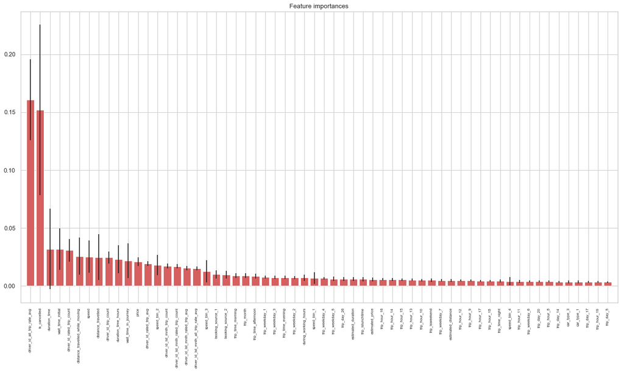

```python
##Extra Tree Classifier for feature importance
# train_x.drop(['driver_id_all_trip_rate_avg','is_cancelled'],axis=1, inplace=True)
et = ExtraTreesClassifier(n_estimators = 100, random_state = 100, min_samples_leaf = 3, n_jobs = -1)

et.fit(train_x, train_y)

X= train_x
y= train_y
importances = et.feature_importances_
std = np.std([tree.feature_importances_ for tree in et.estimators_], axis=0)
indices = np.argsort(importances)[::-1]

# Print the feature ranking
print("Feature ranking:")

for f in range(X.shape[1]):
    print("%d. feature %d : %s (%f)" % (f + 1, indices[f],X.columns[indices[f]], importances[indices[f]]))

featuretoplot =60# number of features to plot, use X.shape[1] if you want to plot all features

#Plot the feature importances of the forest
plt.figure(figsize=(20, 10), dpi=80)
plt.title("Feature importances")
#plt.bar(range(X.shape[1]), importances[indices],color="r", yerr=std[indices], align="center")
plt.bar(range(featuretoplot), importances[indices][0:featuretoplot],color="r", yerr=std[indices][0:featuretoplot], align="center")
#plt.xticks(range(X.shape[1]), indices)
plt.xticks(range(featuretoplot), X.columns[indices[0:featuretoplot]])
plt.xticks(fontsize=10, rotation=90,size=7)
#plt.xlim([-1, X.shape[1]])
plt.xlim([-1, featuretoplot])
plt.show()
```

#### Split the training dataset into 70% Training and 30% Validation

```python
X_train, X_test, y_train, y_test = train_test_split(train_x, train_y, train_size = 0.70,random_state=5055 )
```

#### Build the model using XGB classifier

```
---------------------------------------
23
['driver_id_all_trip_rate_avg', 'is_cancelled', 'duration_time', 'wait_time_initial', 'driver_id_rated_trip_count', 'distance_travelled_while_moving', 'speed', 'distance_travelled', 'driver_id_trip_count', 'duration_time_hours', 'wait_time_in_journey', 'price', 'driver_id_rated_trip_avg', 'speed_bin…
Predicted     0      1    All
Actual
0          1265   3610   4875
1           356  10030  10386
All        1621  13640  15261
 AUC :
--------------
             precision    recall  f1-score   support

          0       0.78      0.26      0.39      4875
          1       0.74      0.97      0.83     10386

avg / total       0.75      0.74      0.69     15261

Accuracy: 0.7401218793001769
```

```
Text(0.5,1,'Reciever operating Charactaristics')
```

```
Text(0.5,0,'False positive rate')
```

```
Text(0,0.5,'True positive rate')
```

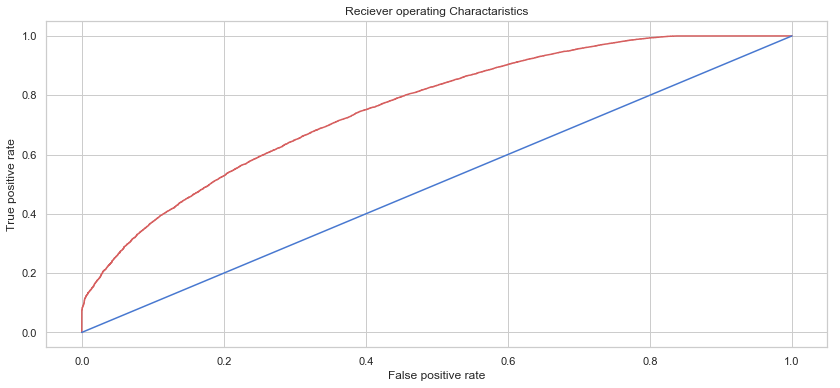

```python
# Loop throughdifferent combination of features based on the sorted list of feature importance.
d = []

prev_feature_len =0

# for threshold in(np.arange(.030, .0080, -0.0001)):
for threshold in [0.0086]:
    print("---------------------------------------")
    features = []
    for i, z in sorted(zip(et.feature_importances_,X_train.columns),reverse=True): # Extra Trees
        if i>round(threshold,4):
            features.append(z)
    xtf = X_train[features]
    xttf = X_test[features]
    ytt = y_test
    yt = y_train
    if len(features) != prev_feature_len:
        prev_feature_len = len(features)
        print(len(features))
        print(features)
        gbm = xgb.XGBClassifier(max_depth=3, n_estimators=300, learning_rate=0.05).fit(xtf, yt)
        y_pred = gbm.predict(xttf)
        con_mtx = confusion_matrix(ytt, y_pred)
        print(pd.crosstab(ytt,y_pred, rownames=['Actual'], colnames=['Predicted'], margins=True))
        y_hat = [x[1] for x in gbm.predict_proba(xttf)]

        auc = roc_auc_score(ytt, y_hat)

        print(" AUC : ".format(auc))
        print ("--------------")
        print(classification_report(ytt, y_pred))
        print(f'Accuracy: {metrics.accuracy_score(y_pred,ytt )}')

        y_proba = gbm.predict_proba(xtf)[:,1]
        fpr,tpr,th = roc_curve(yt,y_proba)

        #Plot ROC
        plt.figure(figsize=(14,6))
        plt.plot(fpr,tpr,color='r')
        plt.plot([0,1],[0,1],color='b')
        plt.title('Reciever operating Charactaristics')
        plt.xlabel('False positive rate')
        plt.ylabel('True positive rate')
        plt.show()
```

#### Try Logistic Regression

```python
LogReg = LogisticRegression()
LogRegResult = LogReg.fit(X_train, y_train)
y_pred = LogRegResult.predict(X_test)
con_mtx = confusion_matrix(y_test, y_pred)
pd.crosstab(y_test,y_pred, rownames=['Actual'], colnames=['Predicted'], margins=True)
# get Correlation Coefficient for each feature using Logistic Regression

coeff_df = pd.DataFrame(X_train.columns)
coeff_df.columns = ['Features']
coeff_df["Coefficient_Estimate"] = pd.Series(LogRegResult.coef_[0])

coeff_df.sort_values(by='Coefficient_Estimate', ascending=False)

y_hat = [x[1] for x in LogRegResult.predict_proba(X_test)]

auc = roc_auc_score(y_test, y_hat)

auc

print(classification_report(y_test, y_pred))
metrics.accuracy_score(y_test, y_pred)
```

| Predicted Actual | 0 | 1 | All |
| --- | --- | --- | --- |
| 0 | 1457 | 3418 | 4875 |
| 1 | 508 | 9878 | 10386 |
| All | 1965 | 13296 | 15261 |

|  | Features | Coefficient_Estimate |
| --- | --- | --- |
| 13 | driver_id_all_trip_rate_avg | 5.841966 |
| 3 | estimated_duration | 1.146228 |
| 24 | booking_source_1 | 0.887326 |
| 25 | booking_source_2 | 0.851169 |
| 10 | driver_id_trip_count | 0.787583 |
| 71 | trip_day_13 | 0.767605 |
| 6 | estimated_price | 0.576829 |
| 77 | trip_day_19 | 0.540966 |
| 96 | trip_weekday_1 | 0.531568 |
| 78 | trip_day_20 | 0.499439 |
| 64 | trip_day_6 | 0.466327 |
| 5 | wait_time_in_journey | 0.402289 |
| 93 | speed_bin_4 | 0.384913 |
| 88 | trip_day_30 | 0.384564 |
| 70 | trip_day_12 | 0.383938 |
| 91 | speed_bin_2 | 0.372632 |
| 28 | car_type_2 | 0.355287 |
| 63 | trip_day_5 | 0.343429 |
| 92 | speed_bin_3 | 0.343205 |
| 90 | speed_bin_1 | 0.341223 |
| 30 | car_type_4 | 0.312549 |
| 95 | speed_bin_6 | 0.309562 |
| 94 | speed_bin_5 | 0.305704 |
| 38 | trip_hour_3 | 0.216621 |
| 26 | booking_source_3 | 0.202459 |
| 102 | trip_weekday_7 | 0.196434 |
| 40 | trip_hour_5 | 0.170363 |
| 33 | trip_time_morning | 0.165283 |
| 22 | trip_isweekend | 0.162869 |
| 87 | trip_day_29 | 0.155350 |
| ... | ... | ... |
| 45 | trip_hour_10 | -0.077033 |
| 29 | car_type_3 | -0.084312 |
| 2 | distance_travelled_while_moving | -0.098647 |
| 19 | trip_month | -0.099253 |
| 21 | during_working_hours | -0.101811 |
| 98 | trip_weekday_3 | -0.106180 |
| 46 | trip_hour_11 | -0.107458 |
| 36 | trip_hour_1 | -0.167088 |
| 60 | trip_day_2 | -0.194203 |
| 27 | car_type_1 | -0.206834 |
| 86 | trip_day_28 | -0.226162 |
| 81 | trip_day_23 | -0.233779 |
| 84 | trip_day_26 | -0.261283 |
| 61 | trip_day_3 | -0.283166 |
| 67 | trip_day_9 | -0.298982 |
| 35 | trip_hour_0 | -0.302429 |
| 16 | driver_id_lst_mnth_rated_trip_avg | -0.310973 |
| 82 | trip_day_24 | -0.319728 |
| 74 | trip_day_16 | -0.345181 |
| 99 | trip_weekday_4 | -0.367341 |
| 68 | trip_day_10 | -0.375364 |
| 75 | trip_day_17 | -0.434653 |
| 1 | distance_travelled | -0.476880 |
| 85 | trip_day_27 | -0.540797 |
| 0 | estimated_distance | -0.543595 |
| 7 | price | -0.907724 |
| 11 | driver_id_rated_trip_count | -1.328282 |
| 4 | wait_time_initial | -2.318415 |
| 12 | driver_id_rated_trip_avg | -2.905357 |
| 8 | is_cancelled | -6.132037 |

103 rows × 2 columns

```
0.7472741708512939
```

```
             precision    recall  f1-score   support

          0       0.74      0.30      0.43      4875
          1       0.74      0.95      0.83     10386

avg / total       0.74      0.74      0.70     15261
```

```
0.7427429395190355
```

### Predict Test dataset results

- Use trained model on the test data set to predict the was_rated flag

```python
# one-hot encoding for category features
trip_test_jnd.columns = [x.lower() for x in trip_test_jnd.columns]
trip_test_jnd.reset_index(drop=True )

cat_cols = ['booking_source','car_type', 'trip_month', 'trip_time', 'trip_hour', 'trip_day', 'speed_bin', 'trip_weekday']
trip_test_jnd = OneHotEncoderfunc(trip_test_jnd, cat_cols)
```

```
Before : (17200, 34)
After : (17200, 112)
```

```python
list(trip_test_jnd.columns)
```

```
['customer_id',
 'driver_id',
 'creation_date',
 'estimated_distance',
 'distance_travelled',
 'distance_travelled_while_moving',
 'estimated_duration',
 'wait_time_initial',
 'wait_time_in_journey',
 'estimated_price',
 'price',
 'is_cancelled',
 'duration_time',
 'driver_id_trip_count',
 'driver_id_rated_trip_count',
 'driver_id_rated_trip_avg',
 'driver_id_all_trip_rate_avg',
 'driver_id_lst_mnth_trip_count',
 'driver_id_lst_mnth_rated_trip_count',
 'driver_id_lst_mnth_rated_trip_avg',
 'driver_id_lst_mnth_all_trip_rate_avg',
 'duration_time_hours',
 'trip_month',
 'speed',
 'during_working_hours',
 'trip_isweekend',
 'trip_islunchtime',
 'booking_source_1',
 'booking_source_2',
 'booking_source_3',
 'booking_source_4',
 'car_type_1',
 'car_type_2',
 'car_type_3',
 'car_type_4',
 'car_type_5',
 'trip_time_Afternoon',
 'trip_time_Evening',
 'trip_time_Morning',
 'trip_time_Night',
```

[output cut: 57 more lines]

```
 'speed_bin_3',
 'speed_bin_4',
 'speed_bin_5',
 'speed_bin_6',
 'speed_bin_7',
 'speed_bin_8',
 'speed_bin_9',
 'speed_bin_10',
 'trip_weekday_1',
 'trip_weekday_2',
 'trip_weekday_3',
 'trip_weekday_4',
 'trip_weekday_5',
 'trip_weekday_6',
 'trip_weekday_7']
```

```python
selected_cols =['driver_id_all_trip_rate_avg', 'is_cancelled', 'duration_time', 'wait_time_initial', 'driver_id_rated_trip_count',
                'distance_travelled_while_moving', 'speed', 'distance_travelled', 'driver_id_trip_count', 'duration_time_hours',
                'wait_time_in_journey', 'price', 'driver_id_rated_trip_avg', 'speed_bin_2', 'driver_id_lst_mnth_trip_count',
                'driver_id_lst_mnth_rated_trip_count', 'driver_id_lst_mnth_rated_trip_avg', 'driver_id_lst_mnth_all_trip_rate_avg',
                'speed_bin_3', 'booking_source_1', 'booking_source_2', 'trip_time_morning', 'trip_month']


y_test_pred = gbm.predict(trip_test_jnd[selected_cols])
```

```python
submission = pd.DataFrame({'customer_id':trip_test['customer_id'],'driver_id':trip_test['driver_id'],'creation_date':trip_test['creation_date'],'was_rated':y_test_pred})
#Visualize the first 5 rows
submission.head()
```

|  | customer_id | driver_id | creation_date | was_rated |
| --- | --- | --- | --- | --- |
| 0 | 60956364 | 1761208 | 2017-09-08 15:11:09.000 | 1 |
| 2 | 55197228 | 1362580 | 2017-09-08 20:54:56.000 | 1 |
| 3 | 53877020 | 1917600 | 2017-09-09 07:15:20.000 | 1 |
| 4 | 12747160 | 2063780 | 2017-09-09 10:38:21.000 | 1 |
| 5 | 9840836 | 1570728 | 2017-09-09 11:25:27.000 | 1 |

```python
submission.to_csv('was_rated_prediction.csv')
```

## Future work

- Continue to predict the rating
- Use cross validation to avoid overfitting
- Use gridsearch to do hyperparameter optimization